# Statistics for Bioengineering - Weeks 7–10

## Calculating F-Ratios

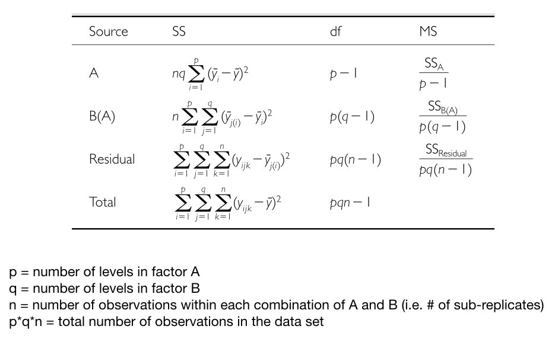

## Multifactor Example

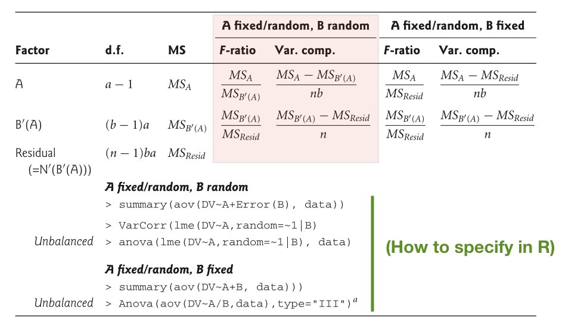

## Multifactor ANOVA Results

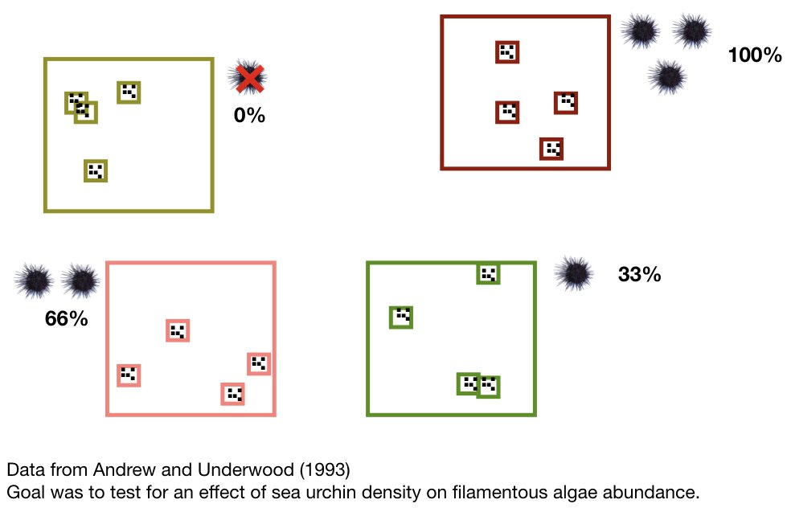

## Interactions

An **interaction** means the effect of one variable on the response depends on the state of another variable.

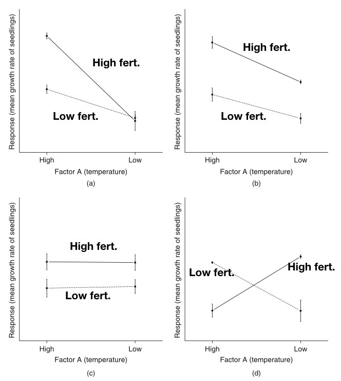

## Visualizing Interactions

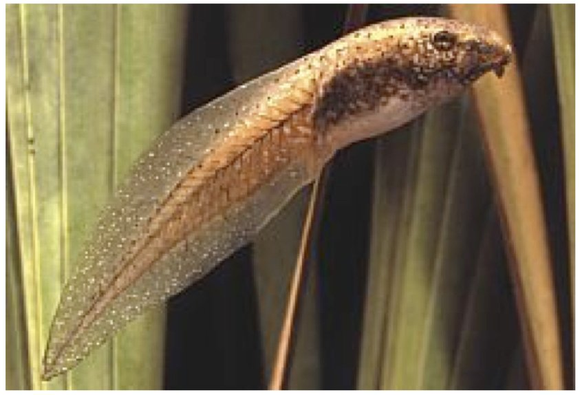

## Interaction Interpretation

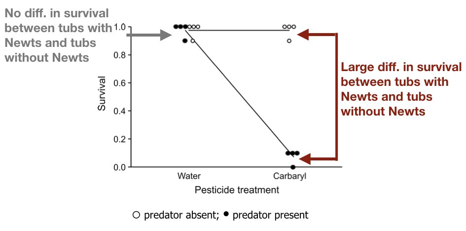

## Factorial vs. Nested Designs

**Factorial designs:**

- All pairwise combinations of factor levels are present
- Can assess interactions between factors
- Example: Drug dose × Exercise regimen

**Nested designs:**

- Hierarchical structure — levels of one factor occur within levels of another
- No interaction terms (levels are unique to each group)
- Often contain random effects
- Example: Cells within wells within plates

## Two-Factor Factorial Design

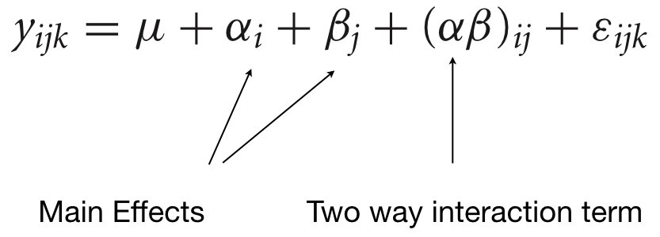

## Three-Factor Factorial Design

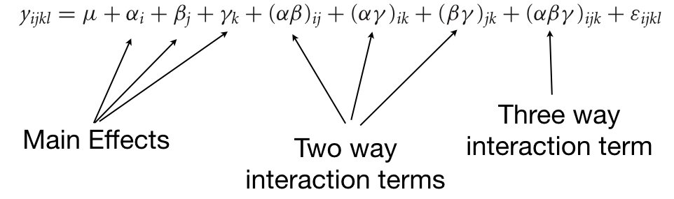

Three-way factorial layout

## Higher-Order Interactions

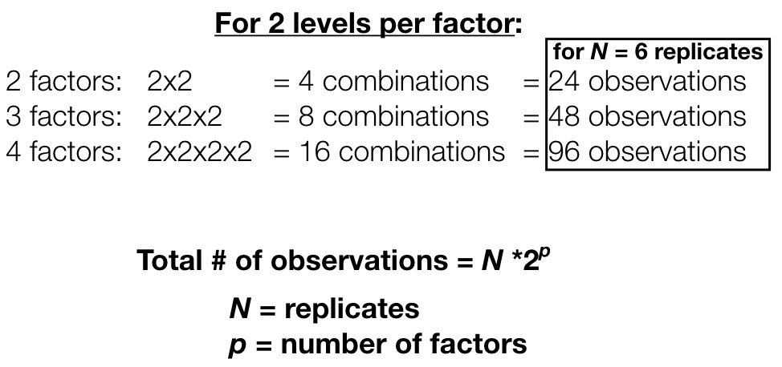

## Complete Factorial Model

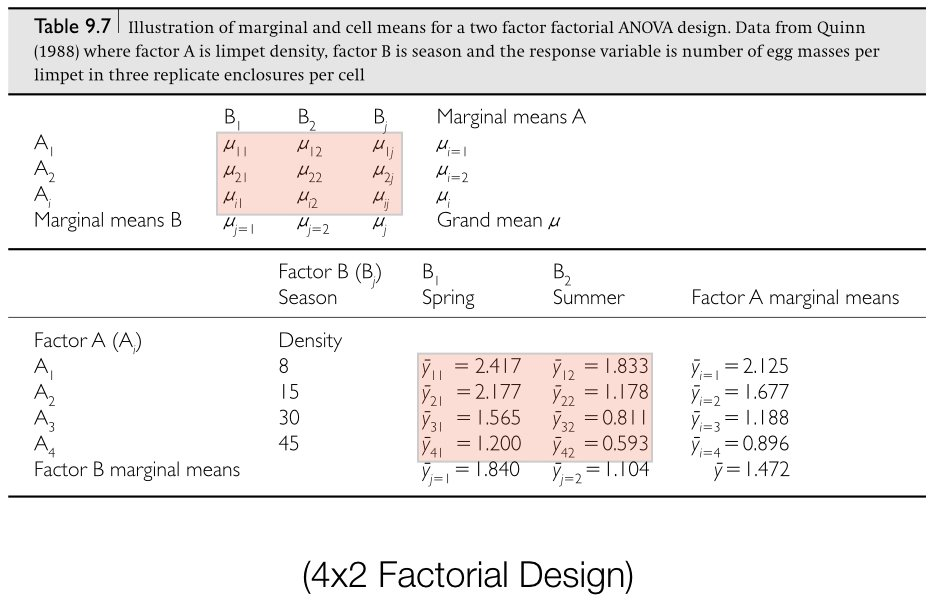

## Factorial ANOVA — Fixed Effects

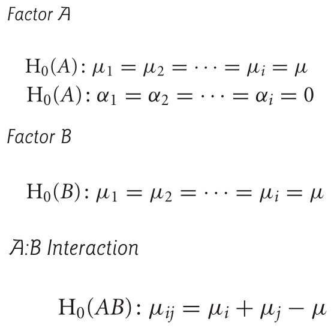

## Factorial ANOVA — Random Effects

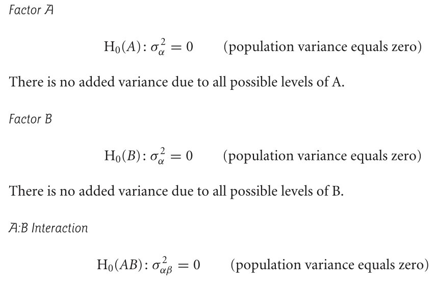

## Mean Squares for Factorial Model

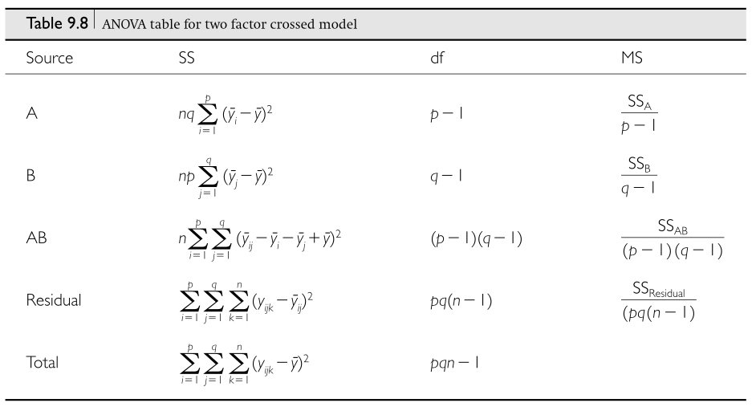

## F-Ratios for Factorial Model

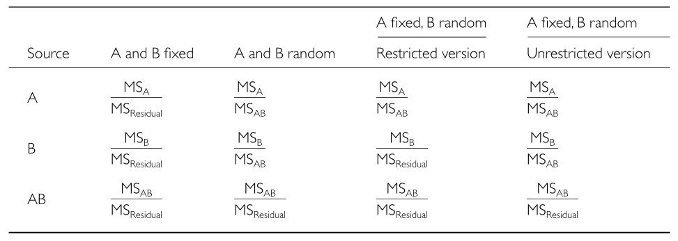

## Interpretation of Results

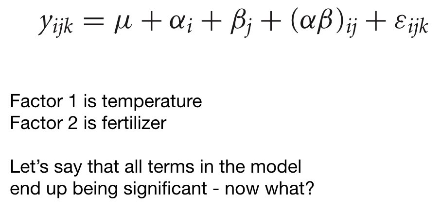

## Factorial ANOVA in R

- Code
- Interpretation

```r
rna_data <- read.table("Stickle_RNAseq.tsv", header = TRUE, sep = "\t")

gene       <- rna_data$Gene100
microbiota <- rna_data$Microbiota
genotype   <- rna_data$Genotype

# Multiplicative model (with interaction)
model_interaction <- aov(gene ~ microbiota * genotype)

# Additive model (no interaction)
model_additive <- aov(gene ~ microbiota + genotype)

summary(model_interaction)
summary(model_additive)
```

- If the interaction term is significant, the effect of one factor depends on the level of the other
- If the interaction is not significant, interpret the main effects directly
- Always check the interaction first before interpreting main effects

# BREAK

# Random Effects

## Fixed vs. Random Effects

**Fixed effects:**

- Groups are predetermined, of direct interest, repeatable
- Examples: medical treatments, predetermined doses, habitat types
- We want to estimate specific group means

**Random effects:**

- Groups randomly sampled from a larger population
- Examples: families, subjects measured repeatedly, blocks, batches
- **Variance among groups** is of interest, not specific group means

## When to Use Random Effects

- Nested sampling designs (individuals within populations)
- Subplots within plots
- Replicates grouped spatially or temporally (blocks, batches)
- Related individuals (families, litters)
- Repeated measures on the same subjects

## Random Effects Hypothesis

- Equation
- LaTeX

$$H_0: \sigma^2_\alpha = 0$$
$$H_A: \sigma^2_\alpha \neq 0$$

```
H_0: \sigma^2_\alpha = 0
H_A: \sigma^2_\alpha \neq 0
```

We are testing whether the **variance component** for the random effect is zero — i.e., whether there is meaningful variation among the randomly sampled groups.

## Random Effects in R

- Code
- Key Points

```r
library(nlme)

# Random effect model
micro_model_random_effect <- lme(
  fixed  = Gene202 ~ 1,
  random = ~1 | Geno.Micro,
  data   = stickle_micro
)

summary(micro_model_random_effect)
```

- In R, `lm()` assumes all effects are **fixed**
- For random effects, use `lme()` from the **nlme** package or `lmer()` from **lme4**
- The `~1 | group` syntax specifies a random intercept for each level of `group`

## Random Effects: Bioengineering Example

Measuring cell viability across multiple wells within multiple plates within multiple experiments:

- Code
- Interpreting Variance Components

```r
# Simulated hierarchical data: cells → wells → plates → experiments
set.seed(42)
n_exp <- 3; n_plate <- 4; n_well <- 6
experiment <- rep(1:n_exp, each = n_plate * n_well)
plate      <- rep(rep(1:n_plate, each = n_well), n_exp)
well       <- rep(1:n_well, n_exp * n_plate)

# Generate data with variance at each level
exp_effect   <- rnorm(n_exp, 0, 5)[experiment]
plate_effect <- rnorm(n_exp * n_plate, 0, 3)[interaction(experiment, plate)]
viability    <- 75 + exp_effect + plate_effect + rnorm(n_exp * n_plate * n_well, 0, 2)

cell_data <- data.frame(
  viability, experiment = factor(experiment),
  plate = factor(plate), well = factor(well)
)

# Fit nested random effects model
library(nlme)
nested_model <- lme(viability ~ 1,
                    random = ~1 | experiment/plate,
                    data = cell_data)
summary(nested_model)

# Extract variance components
VarCorr(nested_model)
```

The output from `VarCorr()` shows:

- **Experiment variance**: variation between experimental runs
- **Plate-within-experiment variance**: variation between plates within a run
- **Residual variance**: well-to-well variation within plates
- ICC (Intraclass Correlation) = group variance / total variance

# Nested ANOVA

## Nested Design

- Factors are hierarchical within one another
- Sources of variance are hierarchical
- No interaction terms (in completely nested designs)

**Example:** Students within classrooms within schools

- Code
- Interpretation

```r
# Nested ANOVA using aov
model_nested <- aov(y ~ A + B %in% A, data = mydata)

# Using lme for random nested effects
model_nested_random <- lme(y ~ A, random = ~1 | A/B, data = mydata)

summary(model_nested_random)
```

- The `%in%` notation means “B is nested within A”
- The `~1 | A/B` random effects specification means “random intercepts for B nested within A”
- Nested designs arise when the levels of one factor are unique to each level of another (e.g., specific cell lines unique to each lab)

# Repeated Measures Analysis

## What are Repeated Measures?

Measurements taken on the **same subjects** at multiple:

- **Time points** (longitudinal studies)
- **Conditions** (within-subjects design)
- **Locations** (spatial sampling)

**Advantages:** Controls for individual differences, requires fewer subjects, more statistical power

**Challenge:** Observations are **not independent** — standard ANOVA assumes independence

## Repeated Measures ANOVA

**Sphericity Assumption:**

- Variances of differences between all pairs of conditions must be equal
- Often violated in practice

**Mauchly’s Test:** Tests the sphericity assumption

- p < 0.05 → sphericity is violated → apply correction (Greenhouse-Geisser or Huynh-Feldt)

## Repeated Measures in R

- Output
- Code

```
Error: subject
          Df Sum Sq Mean Sq F value Pr(>F)
Residuals  9   1572   174.7

Error: subject:time
          Df Sum Sq Mean Sq F value Pr(>F)
time       2   41.5   20.75   0.429  0.657
Residuals 18  869.9   48.33
```

```r
# Create repeated measures data
set.seed(42)
subject <- factor(rep(1:10, each = 3))
time <- factor(rep(c("Pre", "Mid", "Post"), 10))
score <- c(
  rnorm(10, 50, 5),   # Pre
  rnorm(10, 55, 5),   # Mid
  rnorm(10, 62, 5)    # Post
) + rep(rnorm(10, 0, 8), each = 3)  # Subject random effect

rm_data <- data.frame(subject, time, score)

# Repeated measures ANOVA
rm_aov <- aov(score ~ time + Error(subject/time), data = rm_data)
summary(rm_aov)
```

## Mixed Models for Repeated Measures

The modern approach uses **linear mixed models**, which are more flexible and handle missing data gracefully:

- Output
- Code

```
Linear mixed-effects model fit by REML
  Data: rm_data
       AIC      BIC    logLik
  209.8032 216.2823 -99.90158

Random effects:
 Formula: ~1 | subject
        (Intercept) Residual
StdDev:    6.490461 6.951932

Fixed effects:  score ~ time
               Value Std.Error DF   t-value p-value
(Intercept) 53.52105  3.007581 18 17.795381  0.0000
timePost     0.75925  3.108999 18  0.244211  0.8098
timePre     -2.02729  3.108999 18 -0.652073  0.5226
 Correlation:
         (Intr) timPst
timePost -0.517
timePre  -0.517  0.500

Standardized Within-Group Residuals:
       Min         Q1        Med         Q3        Max
-2.1518214 -0.4729270  0.1209759  0.6958689  1.0357408

Number of Observations: 30
Number of Groups: 10
```

```r
library(nlme)

# Mixed model with random intercept for subject
rm_mixed <- lme(score ~ time, random = ~1 | subject, data = rm_data)
summary(rm_mixed)
```

## Visualizing Repeated Measures

- Output
- Code

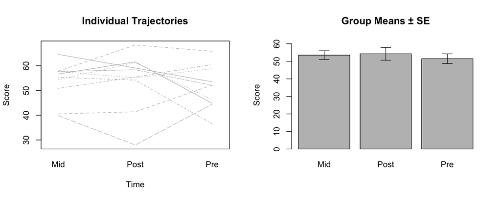

```r
par(mfrow = c(1, 2))

# Spaghetti plot (individual trajectories)
interaction.plot(rm_data$time, rm_data$subject, rm_data$score,
                 xlab = "Time", ylab = "Score", legend = FALSE,
                 main = "Individual Trajectories", col = "gray")

# Group means with error bars
means <- tapply(rm_data$score, rm_data$time, mean)
sds <- tapply(rm_data$score, rm_data$time, sd)
n <- 10
ses <- sds / sqrt(n)

barplot(means, ylim = c(0, max(means) + max(ses) * 2),
        main = "Group Means ± SE", ylab = "Score")
arrows(x0 = c(0.7, 1.9, 3.1), y0 = means - ses,
       y1 = means + ses, angle = 90, code = 3, length = 0.1)
```

## Repeated Measures: ggplot Visualization

- Output
- Code

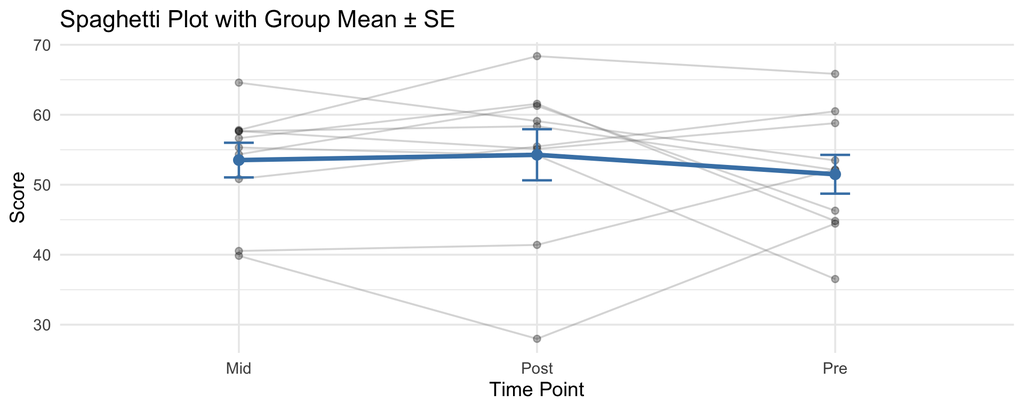

```r
library(ggplot2)

rm_summary <- rm_data %>%
  group_by(time) %>%
  summarize(mean_score = mean(score), se = sd(score)/sqrt(n()))

ggplot(rm_data, aes(x = time, y = score, group = subject)) +
  geom_line(alpha = 0.3, color = "gray50") +
  geom_point(alpha = 0.3) +
  geom_line(data = rm_summary,
            aes(x = time, y = mean_score, group = 1),
            color = "steelblue", linewidth = 1.5) +
  geom_point(data = rm_summary,
             aes(x = time, y = mean_score, group = 1),
             color = "steelblue", size = 3) +
  geom_errorbar(data = rm_summary,
                aes(x = time, y = mean_score,
                    ymin = mean_score - se,
                    ymax = mean_score + se, group = 1),
                width = 0.1, color = "steelblue") +
  labs(title = "Spaghetti Plot with Group Mean ± SE",
       x = "Time Point", y = "Score") +
  theme_minimal()
```

## R Exercise: Factorial ANOVA

**Exercise**

Using the `ToothGrowth` dataset (tooth growth in guinea pigs):

1. Examine the structure: `supp` (supplement type) × `dose` (dose level)
2. Create an interaction plot
3. Perform two-way ANOVA
4. Test for interaction effect
5. If significant interaction, perform simple effects analysis

```r
# Starter code
data(ToothGrowth)
ToothGrowth$dose <- factor(ToothGrowth$dose)

# Interaction plot
interaction.plot(ToothGrowth$dose, ToothGrowth$supp, ToothGrowth$len)

# Two-way ANOVA
tooth_aov <- aov(len ~ supp * dose, data = ToothGrowth)

# Your analysis here...
```

# Week 8: GLMs, Regularization, and Survival Analysis

## Week 8 Topics

- Generalized Linear Models (GLMs)
- Logistic regression
- Poisson regression
- Regularization methods (Ridge, Lasso, Elastic Net)
- Splines and LOESS smoothing
- Survival analysis

**Note**

**Readings:** Chapter 29

**HW4 Due next week**

## Packages for This Week

- Install
- Load

```r
# Install new packages (run once)
install.packages(c("survival", "glmnet", "mgcv", "splines"))
```

```r
# Load packages
library(tidyverse)    # Data manipulation & visualization
library(nlme)         # Mixed-effects models (from Week 7)
library(survival)     # Survival analysis (Kaplan-Meier, Cox regression)
library(glmnet)       # Regularized regression (LASSO, ridge)
library(mgcv)         # Generalized additive models (GAMs)
library(splines)      # Spline basis functions
```

**Datasets from packages:** `lung` (survival package — lung cancer survival data), `mtcars` (built-in)

## Correlation in Mixed Models

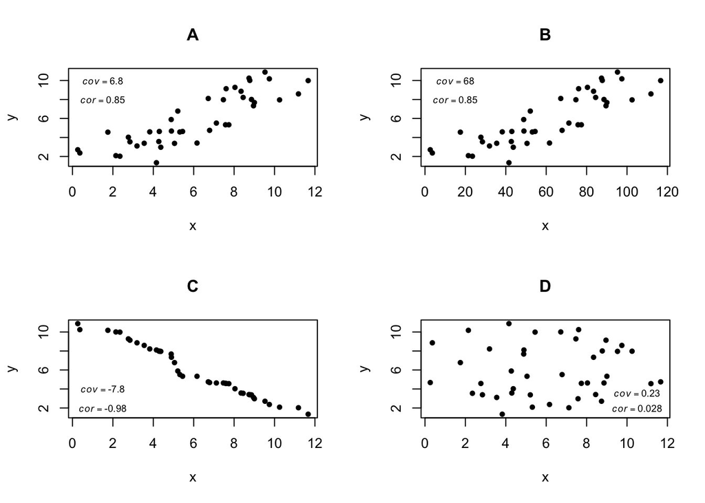

Understanding correlation structures in hierarchical data

# Generalized Linear Models

## What is a GLM?

GLMs extend linear models to handle response variables that are not normally distributed. Use when standard linear model assumptions are violated:

- **Binary response** (e.g., survived/died) → logistic regression
- **Count response** (e.g., number of mutations) → Poisson regression

**Three components of every GLM:**

1. **Random component**: probability distribution of the response variable (e.g., binomial, Poisson)
2. **Systematic component**: linear combination of predictors ($\beta_0 + \beta_1 x_1 + \ldots$)
3. **Link function**: connects the random and systematic components

## GLM Families

| Family | Link Function | Use For | Example |
| --- | --- | --- | --- |
| Gaussian | identity | Continuous response | Standard linear model |
| Binomial | logit | Binary outcomes | Disease presence/absence |
| Poisson | log | Count data | Number of colonies |
| Gamma | inverse | Positive continuous | Reaction times |

## GLM Assumptions

- **Independence** of observations
- No overly **influential observations**
- **Linearity** between predictors and the link function (not between predictors and raw response)
- **Appropriate dispersion** (variance matches the assumed distribution)

## GLM in R

- Code
- Deviance

```r
# General syntax
glm(formula = y ~ x1 + x2,
    family = gaussian(link = "identity"),
    data = mydata)

# Binomial family for logistic regression
glm(y ~ x1 + x2, family = binomial, data = mydata)

# Poisson family for count data
glm(count ~ x1 + x2, family = poisson, data = mydata)
```

- **Deviance** measures model fit in GLMs (analogous to RSS in linear regression)
- **Null Deviance**: from model with only intercept
- **Residual Deviance**: from fitted model
- Large drop from null to residual deviance → better model fit

## GLM Diagnostics

- Code
- DHARMa Interpretation

```r
# Fit a GLM
model <- glm(y ~ x1 + x2, family = binomial, data = mydata)

# Residual deviance plot
plot(predict(model, type = "link"), residuals(model, type = "deviance"),
     xlab = "Linear Predictor", ylab = "Deviance Residuals",
     main = "GLM Deviance Residuals")
abline(h = 0, col = "red", lty = 2)

# Influential observations
plot(cooks.distance(model), type = "h",
     main = "Cook's Distance", ylab = "Cook's Distance")

# DHARMa package for simulation-based diagnostics
library(DHARMa)
sim_res <- simulateResiduals(fittedModel = model, n = 1000)
plot(sim_res)  # QQ plot + residual vs predicted
```

The **DHARMa** package creates simulated residuals that work for any GLM family:

- **QQ plot**: residuals should follow the uniform distribution
- **Residual vs. predicted**: should show no pattern
- **Dispersion test**: detects over/underdispersion
- Works for binomial, Poisson, negative binomial, and zero-inflated models

# BREAK

# Logistic Regression

## What is Logistic Regression?

- Classification algorithm for **binary outcomes** (0/1, yes/no, survived/died)
- Uses the **logit** link function to map outputs between 0 and 1
- Equation
- LaTeX

$$P(y = 1 \mid x) = \frac{1}{1 + e^{-(\beta_0 + \beta_1 x)}}$$

```
P(y = 1 \mid x) = \frac{1}{1 + e^{-(\beta_0 + \beta_1 x)}}
```

## The Logistic Function

- Output
- Code

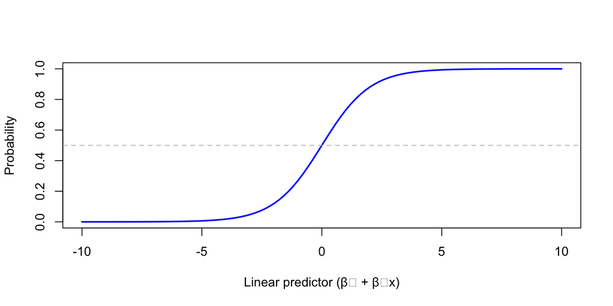

```r
curve(1 / (1 + exp(-x)), from = -10, to = 10, col = "blue", lwd = 2,
      ylab = "Probability", xlab = "Linear predictor (β₀ + β₁x)")
abline(h = 0.5, lty = 2, col = "gray")
```

## Odds and Log-Odds

- Equations
- LaTeX

**Odds:**
$$\frac{P}{1 - P}$$

**Log-odds (logit):**
$$\log\left(\frac{P}{1 - P}\right)$$

**Model equation:**
$$\log\left(\frac{P(y=1)}{1 - P(y=1)}\right) = \beta_0 + \beta_1 x$$

```
\text{Odds} = \frac{P}{1 - P}

\text{Log-odds (logit)} = \log\left(\frac{P}{1 - P}\right)

\text{Model:} \log\left(\frac{P(y=1)}{1 - P(y=1)}\right) = \beta_0 + \beta_1 x
```

## Logistic Regression in R

- Output
- Code

```
Call:
glm(formula = am ~ mpg, family = binomial, data = mtcars)

Coefficients:
            Estimate Std. Error z value Pr(>|z|)
(Intercept)  -6.6035     2.3514  -2.808  0.00498 **
mpg           0.3070     0.1148   2.673  0.00751 **
---
Signif. codes:  0 '***' 0.001 '**' 0.01 '*' 0.05 '.' 0.1 ' ' 1

(Dispersion parameter for binomial family taken to be 1)

    Null deviance: 43.230  on 31  degrees of freedom
Residual deviance: 29.675  on 30  degrees of freedom
AIC: 33.675

Number of Fisher Scoring iterations: 5
```

```r
data(mtcars)
mtcars$am <- factor(mtcars$am)
model <- glm(am ~ mpg, data = mtcars, family = binomial)
summary(model)
```

## Interpreting Coefficients

Coefficients are in **log-odds** — exponentiate to get odds ratios:

- Output
- Code

```
(Intercept)         mpg
0.001355579 1.359379288
```

```r
exp(coef(model))
```

$\exp(\beta_1)$ is the **multiplicative change in odds** for a 1-unit increase in the predictor. For example, if $\exp(\beta_1) = 1.35$, a one-unit increase in mpg multiplies the odds of manual transmission by 1.35 (a 35% increase).

## Bioengineering Example: Predicting Implant Failure

- Code
- Interpretation

```r
# Simulated implant failure data
set.seed(2026)
n <- 150
implant_data <- data.frame(
  surface_roughness = rnorm(n, 1.5, 0.5),     # μm
  coating_thickness = rnorm(n, 50, 15),         # nm
  load_cycles       = rnorm(n, 5e6, 1e6)       # cycles
)
implant_data$failure <- rbinom(n, 1,
  plogis(-3 + 1.5 * implant_data$surface_roughness -
         0.02 * implant_data$coating_thickness +
         0.0000003 * implant_data$load_cycles))

# Fit logistic regression
implant_glm <- glm(failure ~ surface_roughness + coating_thickness + load_cycles,
                    family = binomial, data = implant_data)
summary(implant_glm)

# Odds ratios
exp(coef(implant_glm))
exp(confint(implant_glm))
```

- Higher surface roughness increases odds of failure
- Thicker coating decreases odds of failure
- More load cycles increases odds of failure
- Report odds ratios with 95% CIs for each predictor

## ROC Curve and AUC

- Output
- Code

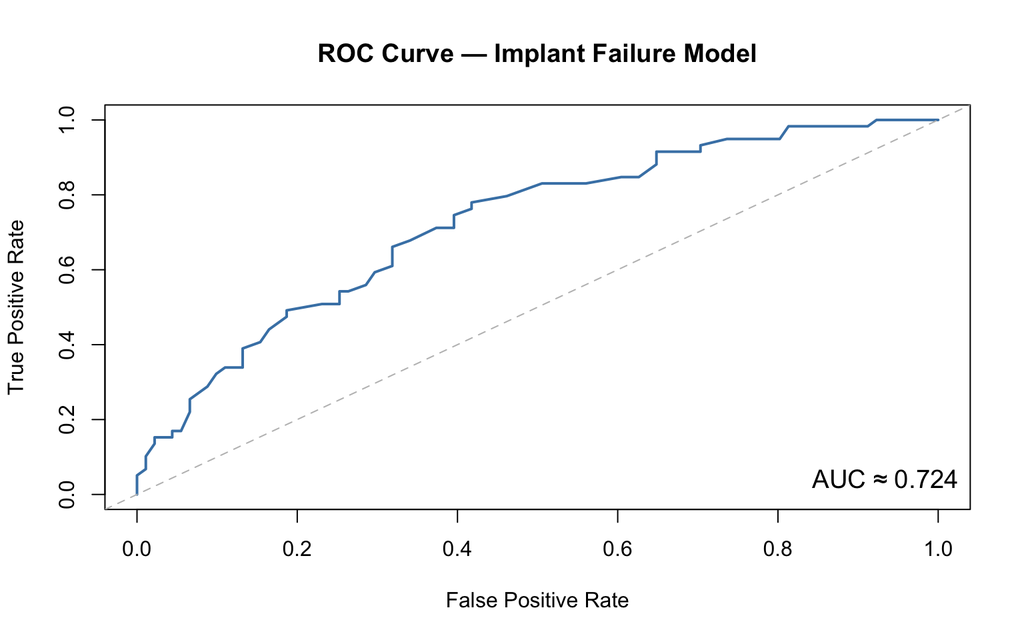

```r
# Using pROC package for ROC curves
library(pROC)

pred_probs <- predict(implant_glm, type = "response")
roc_obj <- roc(implant_data$failure, pred_probs)

# Plot ROC curve
plot(roc_obj, col = "steelblue", lwd = 2,
     main = "ROC Curve — Implant Failure Model")
cat("AUC:", auc(roc_obj))

# Optimal threshold (Youden's J statistic)
coords(roc_obj, "best", ret = c("threshold", "sensitivity", "specificity"))

# Confusion matrix at optimal threshold
optimal_thresh <- coords(roc_obj, "best")$threshold
pred_class <- ifelse(pred_probs >= optimal_thresh, 1, 0)
table(Predicted = pred_class, Actual = implant_data$failure)
```

## Model Evaluation Metrics

| Metric | Formula |
| --- | --- |
| **Accuracy** | $(TP + TN) / (TP + TN + FP + FN)$ |
| **Precision** | $TP / (TP + FP)$ |
| **Recall** | $TP / (TP + FN)$ |
| **F1 Score** | $2 \cdot \frac{Precision \cdot Recall}{Precision + Recall}$ |

## Confusion Matrix

|  | Predicted Positive | Predicted Negative |
| --- | --- | --- |
| **Actual Positive** | True Positive (TP) | False Negative (FN) |
| **Actual Negative** | False Positive (FP) | True Negative (TN) |

# Poisson Regression

## What is Poisson Regression?

Models **count data** where the response variable represents the number of times an event occurs:

- Equation
- LaTeX

$$\log(\lambda_i) = \beta_0 + \beta_1 x_{i1} + \ldots + \beta_p x_{ip}$$

```
\log(\lambda_i) = \beta_0 + \beta_1 x_{i1} + \ldots + \beta_p x_{ip}
```

Assumes Poisson distribution: **Mean = Variance = λ**

## Poisson Regression in R

- Code
- Overdispersion Solutions

```r
# Fit Poisson model
model <- glm(count ~ x1 + x2, family = poisson, data = mydata)

# Check for overdispersion
dispersion <- sum(residuals(model, type = "pearson")^2) / model$df.residual
cat("Dispersion parameter:", dispersion)
# If >> 1, overdispersion is present
```

When variance > mean (overdispersion):

- **Quasi-Poisson**: Adjusts standard errors but keeps same coefficients
- **Negative Binomial**: Adds a parameter for extra-Poisson variation

```r
# Quasi-Poisson
model_qp <- glm(count ~ x1 + x2, family = quasipoisson, data = mydata)

# Negative Binomial
library(MASS)
model_nb <- glm.nb(count ~ x1 + x2, data = mydata)
```

## Poisson Worked Example: Colony Counts

- Output
- Code

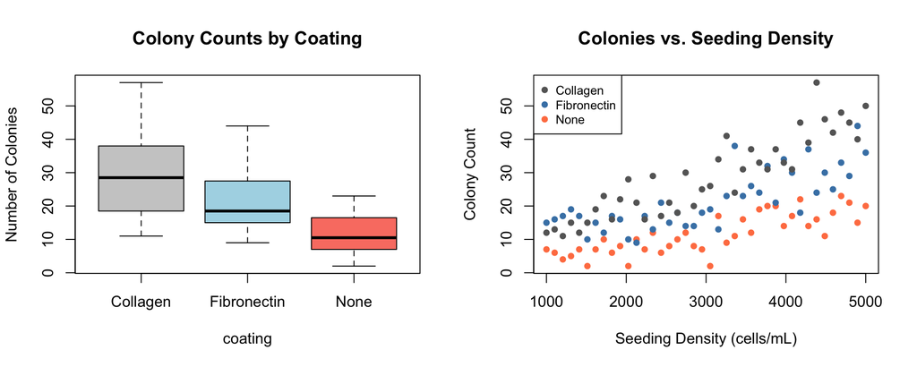

```r
# Bioengineering Poisson regression: bacterial colony counts
# on tissue culture plates with different surface coatings
set.seed(2026)
n <- 120
colony_data <- data.frame(
  coating = factor(rep(c("None", "Fibronectin", "Collagen"), each = 40)),
  seeding = rep(seq(1000, 5000, length.out = 40), 3)
)
colony_data$colonies <- rpois(n, exp(
  1.5 + 0.6 * (colony_data$coating == "Fibronectin") +
  0.9 * (colony_data$coating == "Collagen") +
  0.0003 * colony_data$seeding))

# Fit Poisson GLM
pois_model <- glm(colonies ~ coating + seeding, family = poisson,
                   data = colony_data)
summary(pois_model)

# Check overdispersion
disp <- sum(residuals(pois_model, type = "pearson")^2) / pois_model$df.residual
cat("Dispersion:", round(disp, 2), "\n")

# If overdispersed, compare models
if (disp > 1.5) {
  qp_model <- glm(colonies ~ coating + seeding, family = quasipoisson,
                   data = colony_data)
  nb_model <- MASS::glm.nb(colonies ~ coating + seeding, data = colony_data)

  cat("Poisson AIC:", AIC(pois_model), "\n")
  cat("Neg Binom AIC:", AIC(nb_model), "\n")
}

# Exponentiate for rate ratios
exp(coef(pois_model))
exp(confint(pois_model))
```

## Poisson vs. Quasi-Poisson vs. Negative Binomial

| Model | Dispersion | Use When | R Function |
| --- | --- | --- | --- |
| **Poisson** | φ ≈ 1 | Variance ≈ mean | `glm(..., family = poisson)` |
| **Quasi-Poisson** | φ > 1 | Mild overdispersion | `glm(..., family = quasipoisson)` |
| **Neg. Binomial** | φ >> 1 | Severe overdispersion | `MASS::glm.nb()` |

**Tip**

Always check overdispersion first. If the dispersion parameter is close to 1, standard Poisson is fine. If it exceeds ~1.5, consider quasi-Poisson (same coefficients, wider CIs) or negative binomial (different model entirely).

# Regularization Methods

## Why Regularization?

Standard linear regression struggles when:

- **Multicollinearity**: Correlated predictors lead to unstable coefficient estimates
- **High dimensionality**: More predictors than observations (p > n)
- **Overfitting**: Model fits training data too closely, poor generalization

**Solution**: Add a penalty term that **shrinks coefficients toward zero**, trading a small amount of bias for a large reduction in variance.

## Ridge Regression (L2 Penalty)

- Equation
- LaTeX
- Properties

$$\hat{\beta}_{ridge} = \arg\min_{\beta} \left[ \sum_{i=1}^{n} (y_i - x_i^T\beta)^2 + \lambda \sum_{j=1}^{p} \beta_j^2 \right]$$

```
\hat{\beta}_{ridge} = \arg\min_{\beta} \left[ \sum_{i=1}^{n} (y_i - x_i^T\beta)^2 + \lambda \sum_{j=1}^{p} \beta_j^2 \right]
```

- Penalty: $\sum \beta_j^2$ (L2 norm — sum of squared coefficients)
- Shrinks coefficients toward zero but **never exactly zero**
- Handles multicollinearity well
- Closed-form solution: $\hat{\beta}_{ridge} = (X^TX + \lambda I)^{-1}X^Ty$
- As λ → 0: approaches OLS; as λ → ∞: coefficients → 0

## Lasso Regression (L1 Penalty)

- Equation
- LaTeX
- Properties

$$\hat{\beta}_{lasso} = \arg\min_{\beta} \left[ \sum_{i=1}^{n} (y_i - x_i^T\beta)^2 + \lambda \sum_{j=1}^{p} |\beta_j| \right]$$

```
\hat{\beta}_{lasso} = \arg\min_{\beta} \left[ \sum_{i=1}^{n} (y_i - x_i^T\beta)^2 + \lambda \sum_{j=1}^{p} |\beta_j| \right]
```

- Penalty: $\sum |\beta_j|$ (L1 norm — sum of absolute values)
- Can set coefficients **exactly to zero** → performs variable selection
- No closed-form solution (requires optimization)
- Produces **sparse models** — useful when you believe many predictors are irrelevant

## Elastic Net

Combines Ridge and Lasso penalties:

- Equation
- LaTeX

$$\hat{\beta}_{elastic} = \arg\min_{\beta} \left[ RSS + \lambda \left( \alpha \sum |\beta_j| + (1-\alpha) \sum \beta_j^2 \right) \right]$$

```
\hat{\beta}_{elastic} = \arg\min_{\beta} \left[ RSS + \lambda \left( \alpha \sum |\beta_j| + (1-\alpha) \sum \beta_j^2 \right) \right]
```

- α = 0: pure Ridge; α = 1: pure Lasso
- Variable selection like Lasso + handles correlated features like Ridge
- Often the best default choice

## Regularization in R

- Code
- When to Use

```r
library(glmnet)

# Ridge regression (alpha = 0)
ridge_cv <- cv.glmnet(X_train, y_train, alpha = 0, nfolds = 10)
ridge_model <- glmnet(X_train, y_train, alpha = 0, lambda = ridge_cv$lambda.min)

# Lasso regression (alpha = 1)
lasso_cv <- cv.glmnet(X_train, y_train, alpha = 1, nfolds = 10)
lasso_model <- glmnet(X_train, y_train, alpha = 1, lambda = lasso_cv$lambda.min)

# Elastic net (alpha between 0 and 1)
elastic_cv <- cv.glmnet(X_train, y_train, alpha = 0.5, nfolds = 10)
```

| Method | Use When |
| --- | --- |
| **Ridge** | Many predictors, most relevant; multicollinearity |
| **Lasso** | Feature selection important; many irrelevant predictors |
| **Elastic Net** | Groups of correlated predictors; best of both worlds |

## Geometric Interpretation

- **Ridge** constraint region: circle/sphere (smooth boundary) → coefficients shrink continuously
- **Lasso** constraint region: diamond/polytope (corners at axes) → coefficients can be exactly zero at the corners
- The intersection of the elliptical RSS contours with the constraint region determines the solution

## Visualizing Regularization Paths

- Code
- Interpretation

```r
# Fit models across range of lambda values
ridge_path <- glmnet(X_train, y_train, alpha = 0)
lasso_path <- glmnet(X_train, y_train, alpha = 1)

# Plot coefficient paths
par(mfrow = c(1, 2))
plot(ridge_path, xvar = "lambda", main = "Ridge Regression Path")
plot(lasso_path, xvar = "lambda", main = "Lasso Regression Path")
```

- Each line represents one coefficient as λ changes
- Ridge: all coefficients shrink together toward zero
- Lasso: coefficients drop to exactly zero at different λ values
- Cross-validation selects the optimal λ

## Regularization Worked Example: Biomaterial Properties

- Code
- Visualization

```r
library(glmnet)

# Simulated biomaterial data: 15 material properties predicting biocompatibility
set.seed(42)
n <- 100; p <- 15
X <- matrix(rnorm(n * p), n, p)
colnames(X) <- paste0("property_", 1:p)
# Only 4 properties actually matter
y <- 3 * X[,1] - 2 * X[,3] + 1.5 * X[,7] + 0.8 * X[,12] + rnorm(n, 0, 2)

# Step 1: Scale predictors (glmnet does this by default)
# Step 2: Split data
set.seed(42)
train_idx <- sample(n, 0.7 * n)
X_train <- X[train_idx, ]; y_train <- y[train_idx]
X_test  <- X[-train_idx, ]; y_test  <- y[-train_idx]

# Step 3: Fit with cross-validation
lasso_cv <- cv.glmnet(X_train, y_train, alpha = 1, nfolds = 10)
ridge_cv <- cv.glmnet(X_train, y_train, alpha = 0, nfolds = 10)

# Step 4: Optimal lambda
cat("Lasso lambda.min:", lasso_cv$lambda.min, "\n")
cat("Ridge lambda.min:", ridge_cv$lambda.min, "\n")

# Step 5: Extract coefficients — which properties are selected?
lasso_coefs <- coef(lasso_cv, s = "lambda.min")
print(lasso_coefs)

# Step 6: Compare test set performance
lasso_pred <- predict(lasso_cv, X_test, s = "lambda.min")
ridge_pred <- predict(ridge_cv, X_test, s = "lambda.min")
ols_model  <- lm(y_train ~ X_train)
ols_pred   <- cbind(1, X_test) %*% coef(ols_model)

cat("Test RMSE — Lasso:", sqrt(mean((y_test - lasso_pred)^2)), "\n")
cat("Test RMSE — Ridge:", sqrt(mean((y_test - ridge_pred)^2)), "\n")
cat("Test RMSE — OLS:  ", sqrt(mean((y_test - ols_pred)^2)), "\n")
```

```r
# Plot cross-validation curves
par(mfrow = c(1, 2))
plot(lasso_cv, main = "Lasso CV")
plot(ridge_cv, main = "Ridge CV")

# Coefficient path showing variable selection
plot(glmnet(X_train, y_train, alpha = 1), xvar = "lambda",
     main = "Lasso Coefficient Path")
abline(v = log(lasso_cv$lambda.min), lty = 2, col = "red")
legend("topright", "lambda.min", lty = 2, col = "red", cex = 0.8)
```

# Splines for Non-Linear Relationships

## What are Splines?

Splines are **piecewise polynomials** that create smooth curves by fitting different polynomial segments between data points.

**Types of Spline Fitting:**

- **Regression Splines**: Fit using least squares with specified knots
- **Smoothing Splines**: Balance data fidelity and smoothness automatically
- **Penalized Splines (P-splines)**: Combine B-spline basis with penalties
- **Thin Plate Splines**: Extend to multiple dimensions for spatial data

## Splines in R

- Code
- Key Points

```r
# Natural splines
library(splines)
model_ns <- lm(y ~ ns(x, df = 4), data = mydata)

# Smoothing splines
smooth_fit <- smooth.spline(x, y, cv = TRUE)

# Generalized Additive Models (GAMs)
library(mgcv)
gam_model <- gam(y ~ s(x), data = mydata)

# Thin plate spline for 2D spatial data
model_tp <- gam(z ~ s(x, y, bs = "tp"), data = spatial_data)
```

- Natural splines constrain the tails to be linear (less extrapolation danger)
- GAMs use `s()` to automatically select the amount of smoothing
- Cross-validation (`cv = TRUE`) selects the optimal smoothing parameter

## LOESS Smoothing

LOESS (Locally Estimated Scatterplot Smoothing) fits local polynomial regressions at each point:

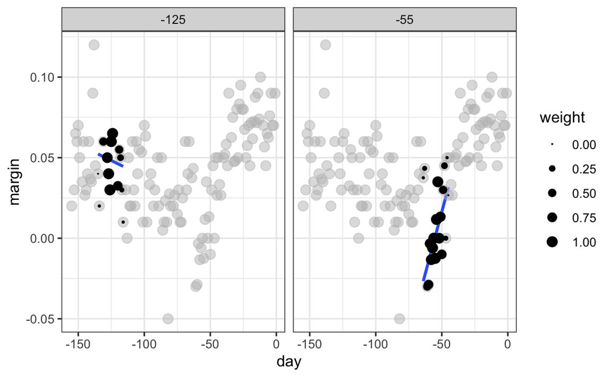

## LOESS Animation

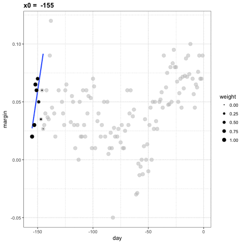

## LOESS with Different Spans

The span parameter controls the smoothness — smaller values create more flexible fits:

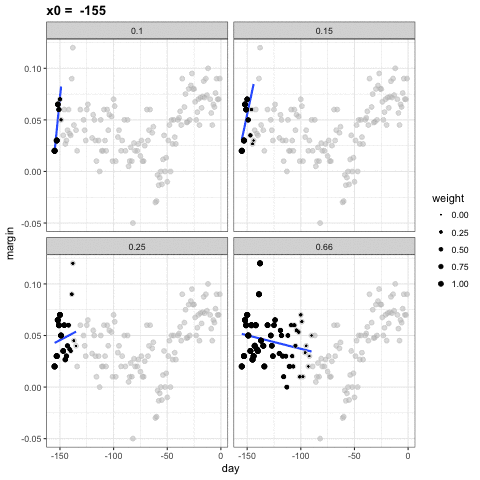

## Comparing Fitting Approaches

- Output
- Code
- Tradeoffs

[figure not shown]

```r
library(splines)
par(mfrow = c(2, 2))

# Linear
m1 <- lm(y ~ x)
plot(x, y, pch = 16, col = "gray60", main = "Linear")
lines(x, predict(m1), col = "steelblue", lwd = 2)

# Polynomial
m2 <- lm(y ~ poly(x, 5))
plot(x, y, pch = 16, col = "gray60", main = "Polynomial (deg 5)")
lines(x, predict(m2), col = "coral", lwd = 2)

# Natural splines
m3 <- lm(y ~ ns(x, df = 5))
plot(x, y, pch = 16, col = "gray60", main = "Natural Splines (df=5)")
lines(x, predict(m3), col = "forestgreen", lwd = 2)

# GAM
m4 <- smooth.spline(x, y, cv = TRUE)
plot(x, y, pch = 16, col = "gray60", main = "GAM")
lines(m4, col = "purple", lwd = 2)
```

| Method | Flexibility | Extrapolation | Interpretability |
| --- | --- | --- | --- |
| Linear | Low | Reasonable | High |
| Polynomial | Medium | Dangerous | Medium |
| Natural splines | High | Linear tails | Medium |
| GAM | High | Auto-tuned | Lower |

# Survival Analysis

## What is Survival Analysis?

**Time-to-event analysis** — studying the time until an event occurs:

- Time until death (clinical trials)
- Time until device failure (bioengineering)
- Time until cell division or apoptosis
- Time until disease recurrence

**Key Features:**

- **Censoring**: Some subjects haven’t experienced the event yet
- **Non-normal data**: Time data is typically right-skewed
- **Hazard rates**: Instantaneous risk of the event at any given time

## Censoring in Survival Data

- Output
- Code

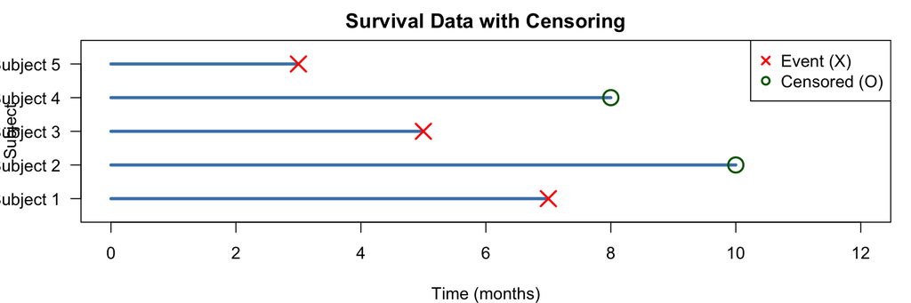

```r
par(mar = c(4, 4, 2, 1))
plot(NULL, xlim = c(0, 12), ylim = c(0.5, 5.5), xlab = "Time (months)",
     ylab = "Subject", main = "Survival Data with Censoring", yaxt = "n")
axis(2, at = 1:5, labels = paste("Subject", 1:5), las = 1)

segments(0, 5, 3, 5, lwd = 3, col = "steelblue")
points(3, 5, pch = 4, cex = 2, col = "red", lwd = 2)
segments(0, 4, 8, 4, lwd = 3, col = "steelblue")
points(8, 4, pch = 1, cex = 2, col = "darkgreen", lwd = 2)
# ... (additional subjects)

legend("topright", c("Event (X)", "Censored (O)"),
       pch = c(4, 1), col = c("red", "darkgreen"), pt.lwd = 2)
```

## The Survival and Hazard Functions

- Equations
- LaTeX

**Survival function:**
$$S(t) = P(T > t) = \text{Probability of surviving past time } t$$

- $S(0) = 1$ (everyone alive at start)
- $S(t)$ decreases over time
- $S(\infty) = 0$ (eventually everyone experiences the event)

**Hazard function:**
$$h(t) = \lim_{\Delta t \to 0} \frac{P(t \leq T < t + \Delta t \mid T \geq t)}{\Delta t}$$

```
S(t) = P(T > t)

h(t) = \lim_{\Delta t \to 0} \frac{P(t \leq T < t + \Delta t \mid T \geq t)}{\Delta t}
```

## Kaplan-Meier Estimator

The **product-limit estimator** for the survival function:

- Equation
- Code

$$\hat{S}(t) = \prod_{t_i \leq t} \left(1 - \frac{d_i}{n_i}\right)$$

Where $d_i$ = events at time $t_i$ and $n_i$ = number at risk before $t_i$

```r
library(survival)
data(lung)

# Fit Kaplan-Meier model
km_fit <- survfit(Surv(time, status) ~ 1, data = lung)

# Plot survival curve
plot(km_fit, xlab = "Time (days)", ylab = "Survival Probability",
     main = "Kaplan-Meier Survival Curve - Lung Cancer",
     col = "steelblue", lwd = 2, conf.int = TRUE)
abline(h = 0.5, lty = 2, col = "red")
```

## Kaplan-Meier Curves

- Output
- Code

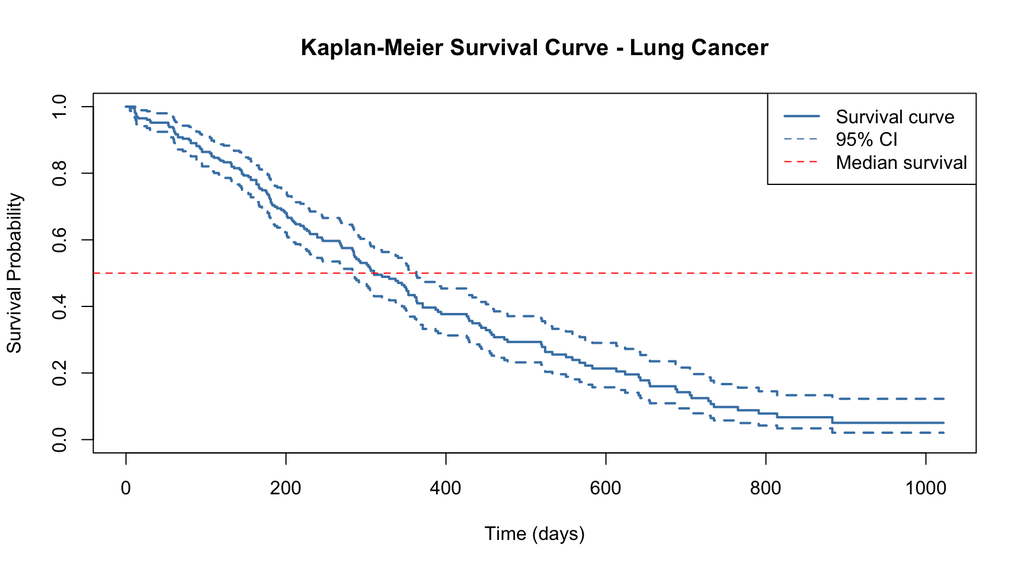

```r
km_fit <- survfit(Surv(time, status) ~ 1, data = lung)

plot(km_fit, xlab = "Time (days)", ylab = "Survival Probability",
     main = "Kaplan-Meier Survival Curve - Lung Cancer",
     col = "steelblue", lwd = 2, conf.int = TRUE)
abline(h = 0.5, lty = 2, col = "red")
legend("topright", c("Survival curve", "95% CI", "Median survival"),
       col = c("steelblue", "steelblue", "red"), lwd = c(2, 1, 1), lty = c(1, 2, 2))
```

## Comparing Survival Curves

- Output
- Code

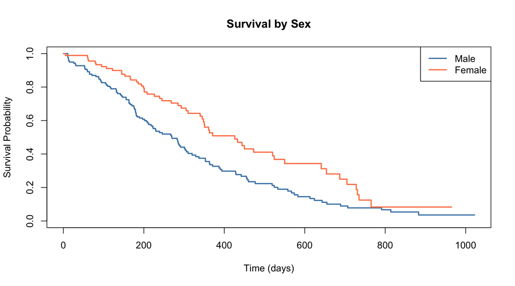

```r
km_sex <- survfit(Surv(time, status) ~ sex, data = lung)
plot(km_sex, col = c("steelblue", "coral"), lwd = 2,
     xlab = "Time (days)", ylab = "Survival Probability",
     main = "Survival by Sex")
legend("topright", c("Male", "Female"), col = c("steelblue", "coral"), lwd = 2)
```

## Log-Rank Test

Tests whether survival curves differ significantly between groups:

- Output
- Code

```
Call:
survdiff(formula = Surv(time, status) ~ sex, data = lung)

        N Observed Expected (O-E)^2/E (O-E)^2/V
sex=1 138      112     91.6      4.55      10.3
sex=2  90       53     73.4      5.68      10.3

 Chisq= 10.3  on 1 degrees of freedom, p= 0.001
```

```r
# Log-rank test comparing survival by sex
survdiff(Surv(time, status) ~ sex, data = lung)
```

## Cox Proportional Hazards Model

**Semi-parametric model** relating covariates to hazard:

- Equation
- Code

$$h(t \mid X) = h_0(t) \cdot \exp(\beta_1 X_1 + \beta_2 X_2 + \ldots)$$

Where $h_0(t)$ is the baseline hazard and $\exp(\beta)$ is the **hazard ratio** for a 1-unit increase.

```r
cox_model <- coxph(Surv(time, status) ~ age + sex + ph.ecog, data = lung)
summary(cox_model)
```

```
Call:
coxph(formula = Surv(time, status) ~ age + sex + ph.ecog, data = lung)

  n= 227, number of events= 164
   (1 observation deleted due to missingness)

             coef exp(coef)  se(coef)      z Pr(>|z|)
age      0.011067  1.011128  0.009267  1.194 0.232416
sex     -0.552612  0.575445  0.167739 -3.294 0.000986 ***
ph.ecog  0.463728  1.589991  0.113577  4.083 4.45e-05 ***
---
Signif. codes:  0 '***' 0.001 '**' 0.01 '*' 0.05 '.' 0.1 ' ' 1

        exp(coef) exp(-coef) lower .95 upper .95
age        1.0111     0.9890    0.9929    1.0297
sex        0.5754     1.7378    0.4142    0.7994
ph.ecog    1.5900     0.6289    1.2727    1.9864

Concordance= 0.637  (se = 0.025 )
Likelihood ratio test= 30.5  on 3 df,   p=1e-06
Wald test            = 29.93  on 3 df,   p=1e-06
Score (logrank) test = 30.5  on 3 df,   p=1e-06
```

## Interpreting Hazard Ratios

- Output
- Code
- Interpretation

```
               HR     2.5 %    97.5 %
age     1.0111282 0.9929281 1.0296620
sex     0.5754446 0.4142130 0.7994351
ph.ecog 1.5899912 1.2726752 1.9864236
```

```r
# Extract hazard ratios with confidence intervals
exp(cbind(HR = coef(cox_model), confint(cox_model)))
```

## Checking Proportional Hazards Assumption

- Output
- Code

```
        chisq df    p
age     0.188  1 0.66
sex     2.305  1 0.13
ph.ecog 2.054  1 0.15
GLOBAL  4.464  3 0.22
```

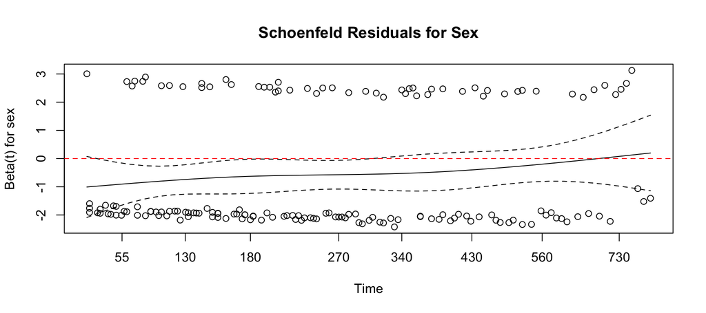

```r
# Test proportional hazards assumption
ph_test <- cox.zph(cox_model)
print(ph_test)

# Visual check — Schoenfeld residuals should show no trend
plot(ph_test[2], main = "Schoenfeld Residuals for Sex")
abline(h = 0, col = "red", lty = 2)
```

## Bioengineering Example: Scaffold Degradation

- Output
- Code
- Interpretation

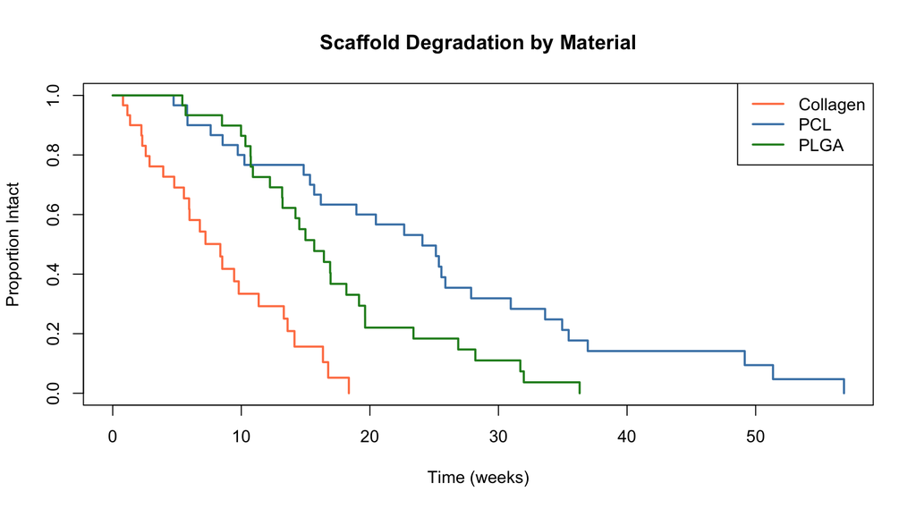

```r
# Simulated scaffold degradation data
set.seed(2026)
scaffold_surv <- data.frame(
  material = factor(rep(c("PLGA", "PCL", "Collagen"), each = 30)),
  time = c(rweibull(30, 2, 14),    # PLGA: moderate degradation
           rweibull(30, 2, 28),     # PCL: slow degradation
           rweibull(30, 1.5, 10)),  # Collagen: fast degradation
  event = rbinom(90, 1, 0.85)      # 85% observed degradation
)

# Kaplan-Meier by material
km_scaffold <- survfit(Surv(time, event) ~ material, data = scaffold_surv)
plot(km_scaffold, col = c("coral", "steelblue", "forestgreen"), lwd = 2,
     xlab = "Time (weeks)", ylab = "Proportion Intact",
     main = "Scaffold Degradation by Material")

# Log-rank test
survdiff(Surv(time, event) ~ material, data = scaffold_surv)

# Cox model: which material degrades fastest?
cox_scaffold <- coxph(Surv(time, event) ~ material, data = scaffold_surv)
summary(cox_scaffold)
exp(cbind(HR = coef(cox_scaffold), confint(cox_scaffold)))
```

[output not shown]

In this bioengineering context:

- **Event** = scaffold degradation (loss of structural integrity)
- **Censored** = scaffold still intact at end of observation period
- **Hazard ratio** = relative rate of degradation vs. reference material
- A higher HR means faster degradation

## R Exercise: Logistic Regression

**Exercise**

A medical researcher wants to predict diabetes using blood glucose and BMI:

```r
# Simulated diabetes data
set.seed(123)
n <- 200
glucose <- rnorm(n, 100, 20)
bmi <- rnorm(n, 27, 5)
prob <- 1 / (1 + exp(-(-8 + 0.05 * glucose + 0.1 * bmi)))
diabetes <- rbinom(n, 1, prob)
diabetes_data <- data.frame(diabetes, glucose, bmi)
```

Tasks:

1. Fit logistic regression: `diabetes ~ glucose + bmi`
2. Interpret the odds ratios (exponentiated coefficients)
3. Predict probability of diabetes for glucose = 120, BMI = 30
4. Create a confusion matrix and calculate accuracy
5. What glucose level gives 50% probability (at mean BMI)?

# Week 9: Statistical Learning and Classification

## Week 9 Topics

- Introduction to statistical learning
- Overfitting and the bias-variance tradeoff
- Cross-validation
- Bayesian statistics
- K-nearest neighbors (KNN)
- Support vector machines (SVM)
- Hierarchical clustering

**Note**

**Readings:** Chapters 30–35

**HW4 Due this week**

## Packages for This Week

- Install
- Load

```r
# Install new packages (run once)
install.packages(c("class", "caret", "cluster", "dendextend", "e1071"))
```

```r
library(tidyverse)    # Data manipulation & visualization
library(boot)         # Bootstrap and cross-validation
library(class)        # K-nearest neighbors (knn)
library(caret)        # Classification And REgression Training
library(cluster)      # Clustering algorithms
library(dendextend)   # Dendrogram visualization
library(e1071)        # Support vector machines (SVM)
library(pwr)          # Power analysis
```

**Built-in datasets used this week:** `iris` (classification example)

# Statistical Learning Overview

## General Steps for Machine Learning

[figure not shown]

Machine learning workflow from data collection to deployment

## What is Statistical Learning?

- A set of tools for **understanding data** through models
- **Supervised learning**: predict an outcome from predictors (requires labeled data)
- **Unsupervised learning**: find patterns without a predefined outcome variable

| Type | Goal | Examples |
| --- | --- | --- |
| Supervised | Predict Y from X | Regression, classification |
| Unsupervised | Find structure in X | Clustering, PCA |

## Machine Learning Steps

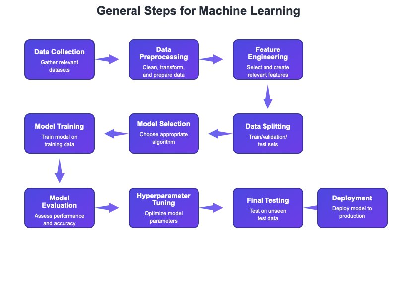

The ML workflow from data to predictions

# The Overfitting Problem

## Overfitting vs. Underfitting

**Underfitting**

- Model too simple
- High bias
- Misses important patterns
- Poor performance everywhere

**Overfitting**

- Model too complex
- High variance
- Memorizes noise
- Great on training, poor on testing

## Bias-Variance Tradeoff

- Equation
- LaTeX

$$\text{Test Error} = \text{Bias}^2 + \text{Variance} + \text{Irreducible Error}$$

```
\text{Test Error} = \text{Bias}^2 + \text{Variance} + \text{Irreducible Error}
```

- **Bias**: error from incorrect model assumptions (too simple)
- **Variance**: error from sensitivity to training data (too complex)
- Goal: balance flexibility with stability

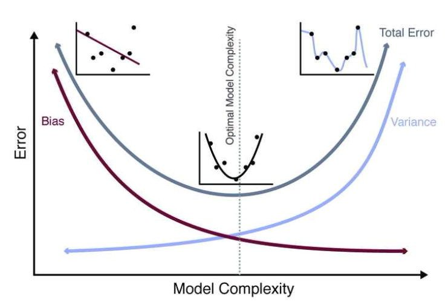

Bias-variance tradeoff

## In-Class Demo: Overfitting in Action

- Output
- Code

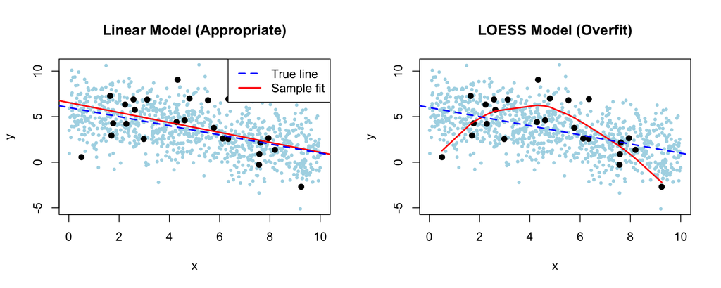

```r
set.seed(1)
x_pop <- runif(1000, 0, 10)
y_pop <- 6 - 0.5 * x_pop + rnorm(1000, sd = 2)

set.seed(0)
idx <- sample(1000, 25)
x_samp <- x_pop[idx]; y_samp <- y_pop[idx]

par(mfrow = c(1, 2))

# Linear model: appropriate fit
plot(x_pop, y_pop, col = "lightblue", pch = 19, cex = 0.5,
     main = "Linear Model (Appropriate)", xlab = "x", ylab = "y")
points(x_samp, y_samp, col = "black", pch = 19)
abline(lm(y_samp ~ x_samp), col = "red", lwd = 2)
abline(a = 6, b = -0.5, col = "blue", lwd = 2, lty = 2)

# LOESS: overfitting
plot(x_pop, y_pop, col = "lightblue", pch = 19, cex = 0.5,
     main = "LOESS Model (Overfit)", xlab = "x", ylab = "y")
points(x_samp, y_samp, col = "black", pch = 19)
lines(sort(x_samp), predict(loess(y_samp ~ x_samp))[order(x_samp)],
      col = "red", lwd = 2)
abline(a = 6, b = -0.5, col = "blue", lwd = 2, lty = 2)
```

# BREAK

# Cross-Validation

## What is Cross-Validation?

- Assess model performance on **unseen data**
- Reduce overfitting by testing generalization
- Compare different models objectively

## Training vs Testing Data

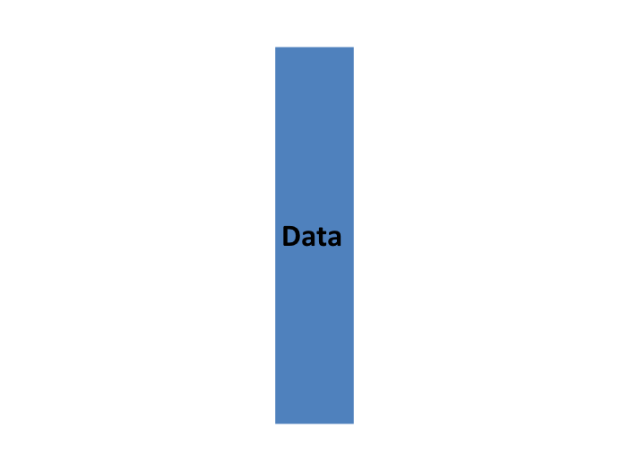

## Overfitting Problem

## K-Fold CV Concept

**Process:**

1. Split data into k folds
2. Train on k − 1 folds
3. Test on remaining fold
4. Repeat k times
5. Average results


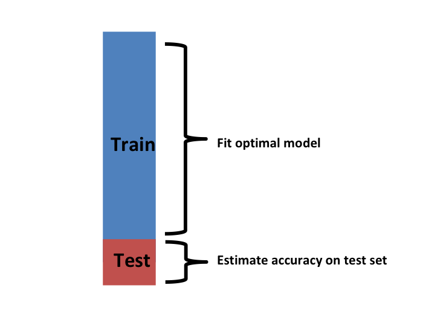

## Model Selection with CV

## CV Summary

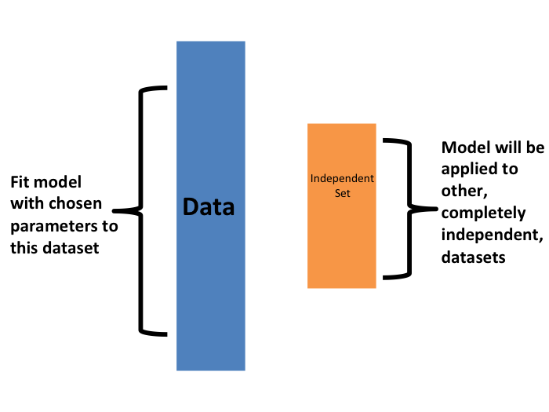

## K-Fold Cross-Validation in R

- Output
- Code

```
10-fold CV MSE: 0.0989
```

```r
library(boot)

set.seed(123)
n <- 100
x <- runif(n, 0, 2 * pi)
y <- sin(x) + rnorm(n, 0, 0.3)
data <- data.frame(x = x, y = y)

model <- glm(y ~ poly(x, 3), data = data)
cv_result <- cv.glm(data, model, K = 10)
cat("10-fold CV MSE:", round(cv_result$delta[1], 4))
```

## Choosing K

| K | Description | Properties |
| --- | --- | --- |
| K = 5 | 5-fold CV | Good balance, common choice |
| K = 10 | 10-fold CV | Most popular default |
| K = n | Leave-one-out (LOOCV) | Maximum training data, expensive |

## CV for Polynomial Degree Selection

- Output
- Code
- Key Insight

[figure not shown]

```r
# LOOCV to select optimal polynomial degree
set.seed(42)
n <- 80
x <- runif(n, 0, 6)
y <- 2 + 3*x - 0.5*x^2 + rnorm(n, 0, 1.5)
df <- data.frame(x, y)

cv_errors <- numeric(10)
for (d in 1:10) {
  cv_err <- 0
  for (i in 1:n) {
    fit <- lm(y ~ poly(x, d), data = df[-i, ])
    pred <- predict(fit, df[i, , drop = FALSE])
    cv_err <- cv_err + (df$y[i] - pred)^2
  }
  cv_errors[d] <- cv_err / n
}

# Plot CV error vs. complexity
plot(1:10, cv_errors, type = "b", pch = 19, col = "steelblue",
     xlab = "Polynomial Degree", ylab = "LOOCV MSE",
     main = "Cross-Validation for Model Selection")
abline(v = which.min(cv_errors), lty = 2, col = "red")

# The "elbow" shows where adding complexity stops helping
cat("Optimal degree:", which.min(cv_errors))
```

- CV error initially decreases as model becomes more flexible
- After the optimal point, overfitting causes CV error to **increase**
- This “elbow” identifies the best bias-variance tradeoff
- Connects directly to model selection from Week 7

# Introduction to Bayesian Statistics

## Frequentist vs. Bayesian

**Frequentist (what we’ve learned so far):**

- Parameters are fixed, unknown constants
- Probability = long-run frequency of events
- Confidence intervals: “95% of such intervals contain the true parameter”
- Focus on p-values and hypothesis tests

**Bayesian:**

- Parameters have **probability distributions**
- Probability = degree of belief
- Credible intervals: “95% probability the parameter is in this range”
- Focus on **posterior distributions**

## Bayes’ Theorem Review

- Equation
- LaTeX
- Components

$$P(\theta \mid data) = \frac{P(data \mid \theta) \cdot P(\theta)}{P(data)}$$

Or more simply:
$$\text{Posterior} \propto \text{Likelihood} \times \text{Prior}$$

```
P(\theta \mid data) = \frac{P(data \mid \theta) \cdot P(\theta)}{P(data)}
```

- **Prior** $P(\theta)$: What we believe before seeing data
- **Likelihood** $P(data \mid \theta)$: How probable the data is given a parameter value
- **Posterior** $P(\theta \mid data)$: Updated belief after seeing data
- The posterior is a compromise between the prior and the data

## Bayesian Estimation: Coin Flip Example

- Output
- Code

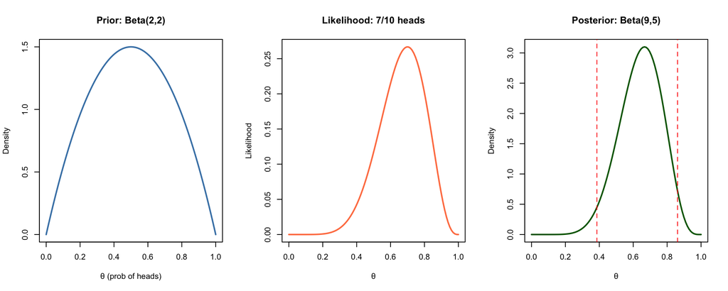

```r
par(mfrow = c(1, 3))
theta <- seq(0, 1, length.out = 100)

# Prior: Beta(2, 2) — slight belief coin is fair
plot(theta, dbeta(theta, 2, 2), type = "l", lwd = 2, col = "steelblue",
     main = "Prior: Beta(2,2)", xlab = "θ (prob of heads)", ylab = "Density")

# Likelihood (binomial): 7 heads out of 10 flips
plot(theta, dbinom(7, 10, theta), type = "l", lwd = 2, col = "coral",
     main = "Likelihood: 7/10 heads", xlab = "θ", ylab = "Likelihood")

# Posterior: Beta(2+7, 2+3) = Beta(9, 5)
plot(theta, dbeta(theta, 9, 5), type = "l", lwd = 2, col = "darkgreen",
     main = "Posterior: Beta(9,5)", xlab = "θ", ylab = "Density")
abline(v = qbeta(c(0.025, 0.975), 9, 5), lty = 2, col = "red")
```

## Credible Intervals

- Output
- Code

```
Posterior mean: 0.643
```

```
95% Credible Interval: 0.386 0.861
```

[output not shown]

[output not shown]

```r
# Posterior: Beta(9, 5)
posterior_mean <- 9 / (9 + 5)
credible_interval <- qbeta(c(0.025, 0.975), 9, 5)

cat("Posterior mean:", round(posterior_mean, 3), "\n")
cat("95% Credible Interval:", round(credible_interval, 3))
```

## Bayesian Linear Regression Concept

- Output
- Code

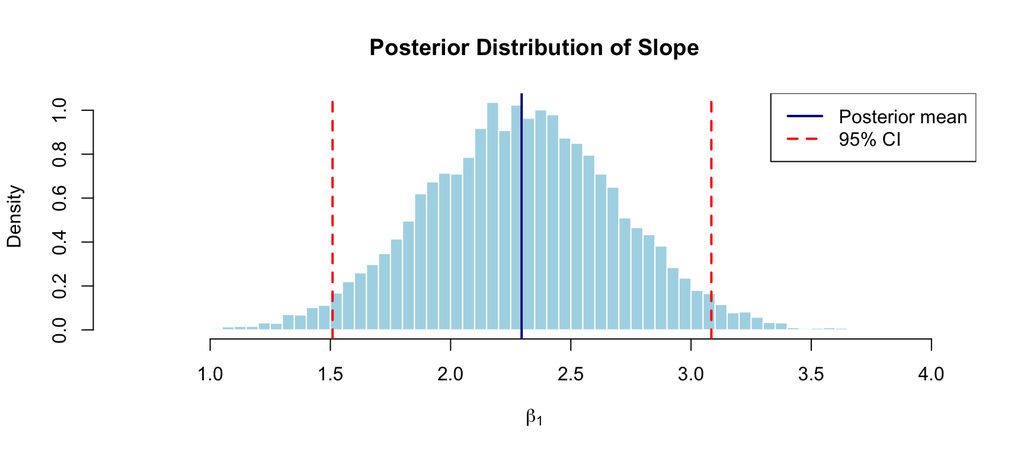

```r
set.seed(42)
beta1_samples <- rnorm(10000, mean = 2.3, sd = 0.4)

hist(beta1_samples, breaks = 50, col = "lightblue", border = "white",
     main = "Posterior Distribution of Slope",
     xlab = expression(beta[1]), probability = TRUE)
abline(v = quantile(beta1_samples, c(0.025, 0.975)), col = "red", lwd = 2, lty = 2)
abline(v = mean(beta1_samples), col = "darkblue", lwd = 2)
```

## When to Use Bayesian Methods

**Consider Bayesian When:**

1. **Prior information exists** — previous studies, expert knowledge
2. **Small sample sizes** — priors stabilize estimates
3. **Complex models** — hierarchical models, missing data
4. **Direct probability statements** — “90% chance effect is positive”
5. **Sequential updating** — accumulating evidence over time

**R Packages for Bayesian Analysis:**

- **rstanarm**: Easy Bayesian regression (similar syntax to lm/glm)
- **brms**: Flexible Bayesian models
- **BayesFactor**: Bayesian hypothesis testing

## Bayesian Regression in Practice

- Code
- Posterior Visualization
- Key Differences from Frequentist

```r
# Install: install.packages("rstanarm")
library(rstanarm)

# Frequentist linear regression
freq_model <- lm(Petal.Length ~ Sepal.Length + Sepal.Width,
                 data = iris)
summary(freq_model)

# Bayesian equivalent — nearly identical syntax!
bayes_model <- stan_glm(Petal.Length ~ Sepal.Length + Sepal.Width,
                        data = iris,
                        family = gaussian(),
                        prior = normal(0, 5),         # weakly informative
                        prior_intercept = normal(0, 10),
                        chains = 4, iter = 2000, seed = 42)

# Posterior summary
print(bayes_model, digits = 3)

# 95% credible intervals
posterior_interval(bayes_model, prob = 0.95)

# Compare to frequentist CIs
confint(freq_model)
```

```r
# Plot posterior distributions of coefficients
plot(bayes_model, plotfun = "areas", prob = 0.95,
     pars = c("Sepal.Length", "Sepal.Width"))

# Posterior predictive check: does the model generate
# data that looks like the real data?
pp_check(bayes_model, plotfun = "dens_overlay", nreps = 50)

# Probability that Sepal.Length effect is positive
posterior_draws <- as.data.frame(bayes_model)
cat("P(Sepal.Length > 0) =",
    mean(posterior_draws$Sepal.Length > 0))
```

- **Credible intervals** have a direct probability interpretation (unlike CIs)
- **Posterior predictive checks** tell you if the model is adequate
- With weak priors and enough data, Bayesian and frequentist results converge
- Bayesian approach naturally handles small samples and complex models

# K-Nearest Neighbors (KNN)

## What is KNN?

KNN is a **lazy learning** algorithm that makes predictions based on the k nearest neighbors in the feature space.

- Non-parametric method
- Instance-based learning (no explicit training phase)
- Used for both classification and regression
- “Tell me who your neighbors are, and I’ll tell you who you are”

## KNN and Overfitting

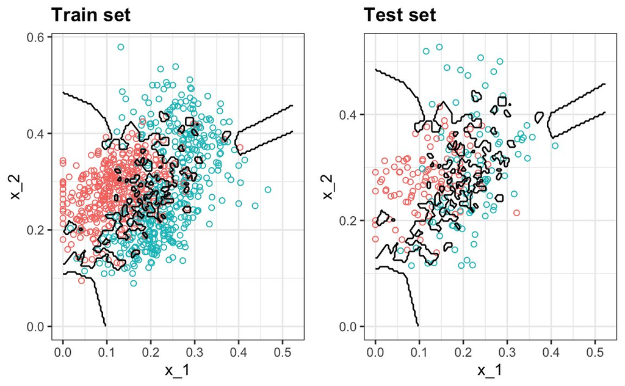

Choosing the right value of k is crucial: k too small → overfitting; k too large → underfitting.

## KNN Algorithm Steps

1. **Choose** the number of neighbors (k)
2. **Calculate** distance between the query point and all training points
3. **Sort** distances and identify k nearest neighbors
4. **Classify** based on majority vote (classification) or average (regression)

## Distance Metrics for KNN

- Equations
- LaTeX

**Euclidean Distance:**
$$d(x_i, x_j) = \sqrt{\sum_{l=1}^{p}(x_{il} - x_{jl})^2}$$

**Manhattan Distance:**
$$d(x_i, x_j) = \sum_{l=1}^{p}|x_{il} - x_{jl}|$$

**Minkowski Distance (generalized):**
$$d(x_i, x_j) = \left(\sum_{l=1}^{p}|x_{il} - x_{jl}|^q\right)^{1/q}$$

```
d_{Euclidean} = \sqrt{\sum_{l=1}^{p}(x_{il} - x_{jl})^2}

d_{Manhattan} = \sum_{l=1}^{p}|x_{il} - x_{jl}|

d_{Minkowski} = \left(\sum_{l=1}^{p}|x_{il} - x_{jl}|^q\right)^{1/q}
```

## KNN Classification in R

- Code
- Choosing Optimal K

```r
library(class)

# Prepare data
train_features <- train_data[, c("x1", "x2")]
train_labels   <- train_data$class
test_features  <- test_data[, c("x1", "x2")]

# Apply KNN
k <- 5
knn_pred <- knn(train = train_features,
                test  = test_features,
                cl    = train_labels,
                k     = k)

# Calculate accuracy
accuracy <- mean(knn_pred == test_labels)
cat("Accuracy:", accuracy)
```

```r
library(caret)

# Cross-validation for optimal k
ctrl <- trainControl(method = "cv", number = 10)

knn_model <- train(class ~ x1 + x2,
                   data = train_data,
                   method = "knn",
                   trControl = ctrl,
                   tuneGrid = data.frame(k = 1:20))

plot(knn_model)
```

## KNN Pros and Cons

**Advantages:** Simple to understand, no assumptions about data distribution, works well with small datasets, naturally handles multi-class problems

**Disadvantages:** Computationally expensive for large datasets, sensitive to irrelevant features and scale, performance degrades in high dimensions (curse of dimensionality)

**Tip**

Always **standardize features** before applying KNN — otherwise variables measured on larger scales will dominate the distance calculations.

## Complete KNN Workflow

- Code
- Decision Boundaries

```r
# Step 1: Prepare and normalize data
data(iris)
iris_sub <- iris[iris$Species != "setosa", ]  # 2-class problem
iris_sub$Species <- droplevels(iris_sub$Species)

# Step 2: Normalize features (critical for KNN!)
normalize <- function(x) (x - min(x)) / (max(x) - min(x))
iris_norm <- as.data.frame(lapply(iris_sub[, 1:4], normalize))
iris_norm$Species <- iris_sub$Species

# Step 3: Train/test split
set.seed(42)
train_idx <- sample(nrow(iris_norm), 0.7 * nrow(iris_norm))
train <- iris_norm[train_idx, ]
test  <- iris_norm[-train_idx, ]

# Step 4: Fit and evaluate across k values
library(class)
k_values <- seq(1, 25, by = 2)
accuracies <- sapply(k_values, function(k) {
  pred <- knn(train[, 1:4], test[, 1:4], train$Species, k = k)
  mean(pred == test$Species)
})
best_k <- k_values[which.max(accuracies)]
cat("Best k:", best_k, "with accuracy:", max(accuracies))

# Step 5: Final model and confusion matrix
final_pred <- knn(train[, 1:4], test[, 1:4], train$Species, k = best_k)
table(Predicted = final_pred, Actual = test$Species)
```

```r
# Visualize decision boundaries for different k values
library(class)

# Use 2 features for visualization
x1_range <- seq(0, 1, length.out = 100)
x2_range <- seq(0, 1, length.out = 100)
grid <- expand.grid(x1 = x1_range, x2 = x2_range)

par(mfrow = c(1, 3))
for (k in c(1, 7, 25)) {
  pred_grid <- knn(train[, 3:4], grid, train$Species, k = k)
  plot(grid$x1, grid$x2, col = ifelse(pred_grid == "versicolor",
       rgb(0.7, 0.7, 1, 0.3), rgb(1, 0.7, 0.7, 0.3)),
       pch = 15, cex = 0.5, main = paste("k =", k),
       xlab = "Petal.Length", ylab = "Petal.Width")
  points(train[, 3], train[, 4],
         col = ifelse(train$Species == "versicolor", "blue", "red"),
         pch = 19)
}
```

# BREAK

# Support Vector Machines (SVM)

## What are Support Vector Machines?

SVMs find the optimal **hyperplane** (decision boundary) that separates classes with the **maximum margin**.

- **Hyperplane**: Decision boundary that separates classes
- **Support Vectors**: Data points closest to the hyperplane (the critical observations)
- **Margin**: Distance between the hyperplane and the nearest points
- **Maximum Margin**: SVM finds the hyperplane with the largest margin

## Mathematical Foundation

- Equation
- LaTeX
- Parameters

Minimize:
$$\frac{1}{2}||w||^2 + C\sum_{i=1}^{n}\xi_i$$

Subject to: $y_i(w^T x_i + b) \geq 1 - \xi_i$ and $\xi_i \geq 0$

```
\min \frac{1}{2}||w||^2 + C\sum_{i=1}^{n}\xi_i

\text{s.t. } y_i(w^T x_i + b) \geq 1 - \xi_i, \quad \xi_i \geq 0
```

- $w$: weight vector (defines hyperplane orientation)
- $b$: bias term
- $C$: regularization parameter (tradeoff between margin width and misclassification)
- $\xi_i$: slack variables (allow some misclassification for soft-margin SVM)

## The Kernel Trick

**Problem**: What if data is not linearly separable?

**Solution**: Map data to a higher-dimensional space using **kernel functions** where it becomes linearly separable.

**Popular Kernels:**

- **Linear**: $K(x_i, x_j) = x_i^T x_j$
- **Polynomial**: $K(x_i, x_j) = (x_i^T x_j + 1)^d$
- **RBF (Radial Basis Function)**: $K(x_i, x_j) = \exp(-\gamma ||x_i - x_j||^2)$

## Kernel Trick Visualization

[figure not shown]

## SVM in R

- Code
- Hyperparameter Tuning

```r
library(e1071)

# Build linear SVM
svm_linear <- svm(y ~ x1 + x2,
                  data = train_data,
                  kernel = "linear",
                  cost = 1)

# Build RBF SVM
svm_rbf <- svm(y ~ x1 + x2,
               data = train_data,
               kernel = "radial",
               cost = 1,
               gamma = 1)

# Make predictions
predictions <- predict(svm_rbf, test_data)
```

```r
# Grid search for optimal parameters
tune_result <- tune(svm,
                    y ~ x1 + x2,
                    data = train_data,
                    kernel = "radial",
                    ranges = list(
                      cost = c(0.1, 1, 10, 100),
                      gamma = c(0.01, 0.1, 1, 10)
                    ))

print(tune_result$best.parameters)
```

## SVM vs Other Algorithms

| Algorithm | Best For | Pros | Cons |
| --- | --- | --- | --- |
| **SVM** | High-dim, small-medium data | Robust, versatile kernels | Slow on large data |
| **Random Forest** | General purpose, large data | Fast, interpretable | Can overfit |
| **KNN** | Small datasets | Simple, no training | Slow at prediction |

## SVM Decision Boundaries by Kernel

- Output
- Code
- Takeaway

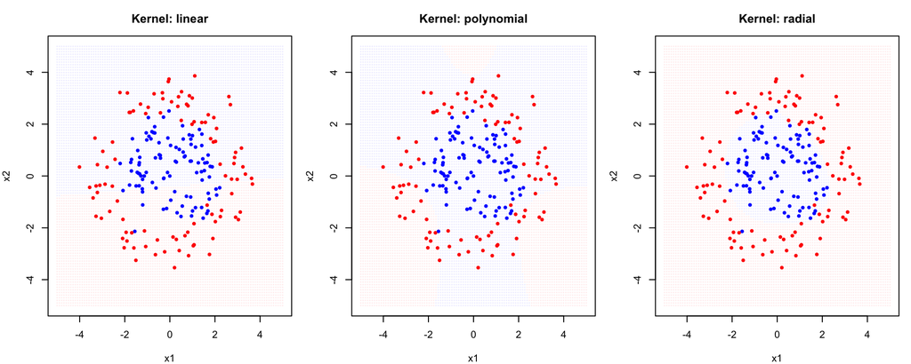

```r
library(e1071)

# Create grid for visualization
grid <- expand.grid(
  x1 = seq(-5, 5, length.out = 100),
  x2 = seq(-5, 5, length.out = 100)
)

par(mfrow = c(1, 3))
for (kern in c("linear", "polynomial", "radial")) {
  fit <- svm(class ~ x1 + x2, data = svm_data,
             kernel = kern, cost = 10, gamma = 0.5)
  pred <- predict(fit, grid)

  plot(grid$x1, grid$x2,
       col = ifelse(pred == "A",
             rgb(0.7, 0.7, 1, 0.2), rgb(1, 0.7, 0.7, 0.2)),
       pch = 15, cex = 0.3, main = paste("Kernel:", kern),
       xlab = "x1", ylab = "x2")
  points(svm_data$x1, svm_data$x2,
         col = ifelse(svm_data$class == "A", "blue", "red"),
         pch = 19, cex = 0.6)
}
```

- **Linear**: Straight boundary — fails on non-linearly separable data
- **Polynomial**: Curved boundary — captures moderate non-linearity
- **RBF (Radial)**: Flexible boundary — captures complex shapes; most versatile

# Hierarchical Clustering

## What is Hierarchical Clustering?

Creates a tree-like structure (**dendrogram**) of nested clusters.

**Two main types:**

1. **Agglomerative (Bottom-up):** Start with each point as its own cluster, merge closest clusters iteratively
2. **Divisive (Top-down):** Start with all points in one cluster, split iteratively

## Dendrogram Example

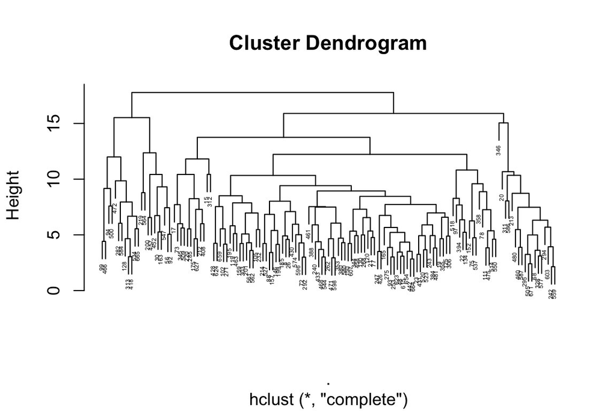

Cut the tree at different heights to get different numbers of clusters.

## Linkage Methods

- Equations
- LaTeX

**Single Linkage (Minimum):**
$$d(C_i, C_j) = \min_{x \in C_i, y \in C_j} d(x, y)$$

**Complete Linkage (Maximum):**
$$d(C_i, C_j) = \max_{x \in C_i, y \in C_j} d(x, y)$$

**Average Linkage:**
$$d(C_i, C_j) = \frac{1}{|C_i||C_j|} \sum_{x \in C_i} \sum_{y \in C_j} d(x, y)$$

**Ward’s Method:** Minimizes within-cluster sum of squares

```
d_{single}(C_i, C_j) = \min_{x \in C_i, y \in C_j} d(x, y)

d_{complete}(C_i, C_j) = \max_{x \in C_i, y \in C_j} d(x, y)

d_{average}(C_i, C_j) = \frac{1}{|C_i||C_j|} \sum \sum d(x, y)
```

## Hierarchical Clustering in R

- Code
- Enhanced Dendrograms

```r
# Calculate distance matrix
dist_matrix <- dist(data, method = "euclidean")

# Perform hierarchical clustering
hclust_ward <- hclust(dist_matrix, method = "ward.D2")

# Plot dendrogram
plot(hclust_ward, main = "Dendrogram (Ward's Method)")

# Cut tree to get clusters
clusters <- cutree(hclust_ward, k = 3)
```

```r
library(dendextend)

dend <- as.dendrogram(hclust_ward)

dend %>%
  color_branches(k = 3) %>%
  color_labels(k = 3) %>%
  plot(main = "Colored Dendrogram")

rect.dendrogram(dend, k = 3, border = "red")
```

## Silhouette Analysis and Cophenetic Correlation

- Silhouette
- Cophenetic Correlation

```r
library(cluster)

# Silhouette scores for different k
silhouette_scores <- numeric(9)
for (k in 2:10) {
  clusters <- cutree(hclust_ward, k = k)
  sil <- silhouette(clusters, dist_matrix)
  silhouette_scores[k - 1] <- mean(sil[, "sil_width"])
}

plot(2:10, silhouette_scores, type = "b",
     xlab = "Number of Clusters",
     ylab = "Average Silhouette Score")
```

```r
# Cophenetic correlation: how well does the dendrogram
# preserve original pairwise distances?
cophenetic_dist <- cophenetic(hclust_ward)
coph_corr <- cor(dist_matrix, cophenetic_dist)
cat("Cophenetic correlation:", round(coph_corr, 3))
# Values closer to 1 = better preservation
```

## Clustered Heatmap

Clustered heatmaps are ubiquitous in genomics and bioengineering — they show both the data and the hierarchical clustering simultaneously.

- Output
- Code
- When to Use

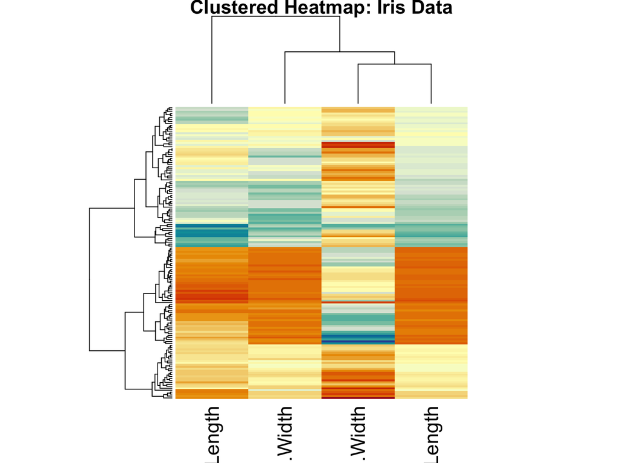

```r
# Base R heatmap (rows and columns clustered automatically)
iris_mat <- as.matrix(iris[, 1:4])
heatmap(iris_mat, scale = "column",
        col = hcl.colors(50, "RdYlBu"),
        main = "Clustered Heatmap: Iris Data")

# Using pheatmap for more control
# install.packages("pheatmap")
library(pheatmap)
annotation_row <- data.frame(Species = iris$Species)
rownames(annotation_row) <- rownames(iris_mat)

pheatmap(iris_mat,
         scale = "column",
         clustering_method = "ward.D2",
         annotation_row = annotation_row,
         show_rownames = FALSE,
         color = hcl.colors(50, "RdYlBu"),
         main = "Iris Features Clustered Heatmap")
```

- **Gene expression** across samples and conditions
- **Biomaterial properties** across formulations
- **Multi-analyte assays** (cytokine panels, metabolomics)
- Any matrix where you want to see patterns in both rows and columns

# K-Means Clustering

## What is K-Means?

K-means partitions data into **k clusters** by minimizing within-cluster variance:

- Algorithm
- Equation
- LaTeX
1. **Initialize** k cluster centers (randomly or with k-means++)
2. **Assign** each point to its nearest center
3. **Update** each center to the mean of its assigned points
4. **Repeat** steps 2–3 until convergence

$$\min_{C_1, \ldots, C_k} \sum_{j=1}^{k} \sum_{x_i \in C_j} ||x_i - \mu_j||^2$$

Where $\mu_j$ is the centroid of cluster $C_j$.

```
\min_{C_1, \ldots, C_k} \sum_{j=1}^{k} \sum_{x_i \in C_j} ||x_i - \mu_j||^2
```

## K-Means in R

- Output
- Code

[figure not shown]

```r
# Scale data first
iris_scaled <- scale(iris[, 1:4])

# Elbow method: find optimal k
wss <- sapply(1:10, function(k) {
  kmeans(iris_scaled, k, nstart = 25)$tot.withinss
})
plot(1:10, wss, type = "b", pch = 19,
     xlab = "k", ylab = "Total Within-SS",
     main = "Elbow Method")

# Fit k-means with chosen k
set.seed(42)
km_fit <- kmeans(iris_scaled, centers = 3, nstart = 25)

# Visualize clusters
plot(iris$Petal.Length, iris$Petal.Width,
     col = km_fit$cluster, pch = 19,
     xlab = "Petal Length", ylab = "Petal Width")

# Compare k-means to true labels
table(Cluster = km_fit$cluster, True = iris$Species)
```

## K-Means vs. Hierarchical Clustering

| Feature | K-Means | Hierarchical |
| --- | --- | --- |
| **Must specify k?** | Yes (in advance) | No (cut tree later) |
| **Cluster shape** | Spherical | Any shape |
| **Scalability** | Fast (large datasets) | Slow (O(n²) or O(n³)) |
| **Deterministic?** | No (random init) | Yes |
| **Visualization** | Scatter plots | Dendrograms |

**Tip**

Use the **elbow method** or **silhouette scores** to choose k for k-means. Consider running both methods and comparing results for robustness.

## R Exercise: Statistical Learning

**Exercise**

Using the `iris` dataset for classification:

1. Split data into training (80%) and test (20%) sets
2. Train a KNN classifier with k = 5 to predict Species
3. Evaluate accuracy on the test set
4. Use cross-validation to find optimal k (1 to 20)
5. Compare to an SVM classifier with RBF kernel

```r
# Starter code
library(class)
set.seed(123)
n <- nrow(iris)
train_idx <- sample(n, 0.8 * n)
train <- iris[train_idx, ]
test  <- iris[-train_idx, ]

# Your analysis here...
```

# Week 10: Multivariate Methods

## Week 10 Topics

- Multivariate statistics overview
- MANOVA
- Discriminant Function Analysis (DFA / LDA)
- Principal Component Analysis (PCA)
- PCoA and NMDS
- t-SNE and UMAP
- Decision trees and random forests

**Note**

**Readings:** Chapters 38–39

## Packages for This Week

- Install
- Load

```r
# Install new packages (run once)
install.packages(c("MASS", "Rtsne", "umap", "vegan",
                   "mvnormtest", "mvoutlier", "rpart", "randomForest"))
```

```r
library(tidyverse)      # Data manipulation & visualization
library(MASS)           # Linear discriminant analysis (LDA)
library(car)            # Multivariate tests
library(Rtsne)          # t-SNE dimensionality reduction
library(umap)           # UMAP dimensionality reduction
library(vegan)          # NMDS and ecological ordination
library(mvnormtest)     # Multivariate normality tests
library(rpart)          # Decision trees
library(randomForest)   # Random forests
```

**Built-in datasets:** `iris` (PCA, LDA, t-SNE, UMAP examples)

## Experimental Design Overview

[figure not shown]

# Introduction to Multivariate Statistics

## Multivariate Data

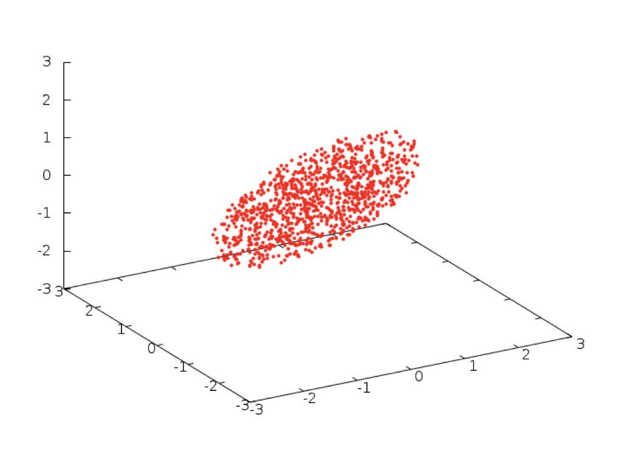

## Multivariate Approach

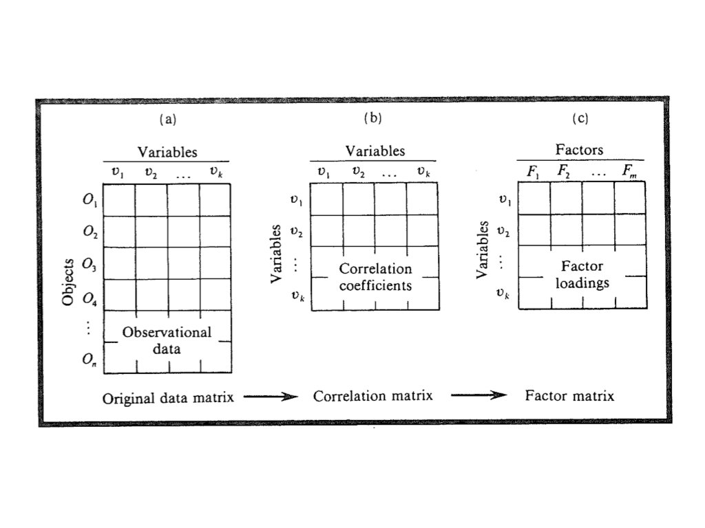

## Multivariate Methods Overview

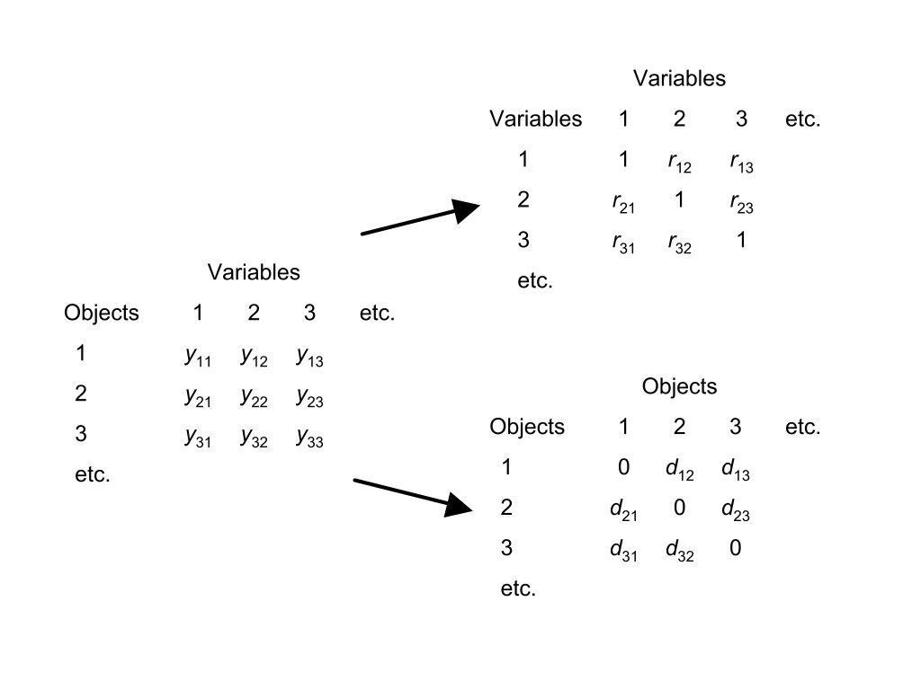

## Variance-Covariance and Eigenvalues

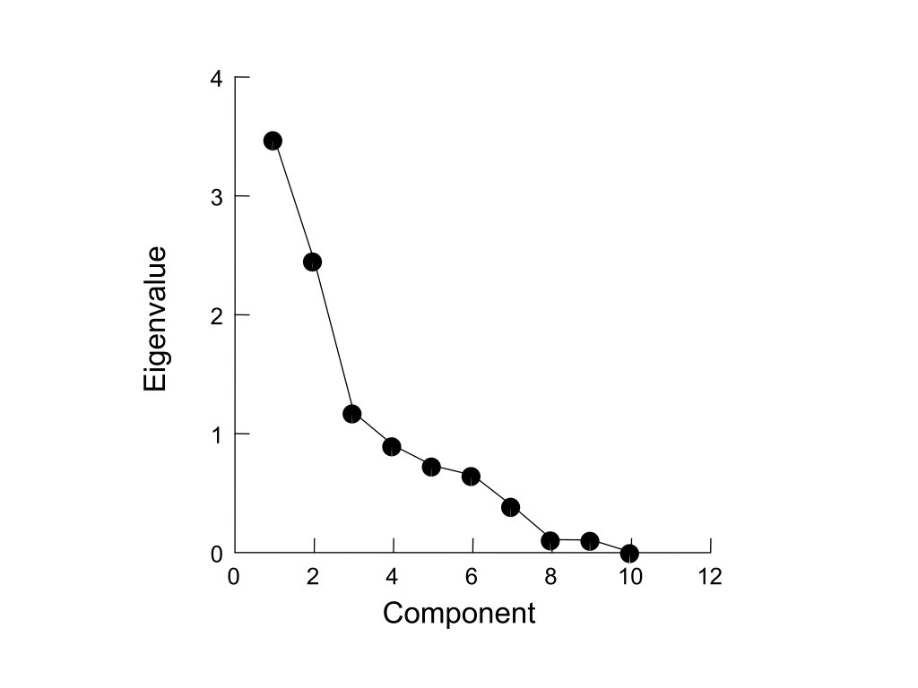

## Dissimilarity and Distance

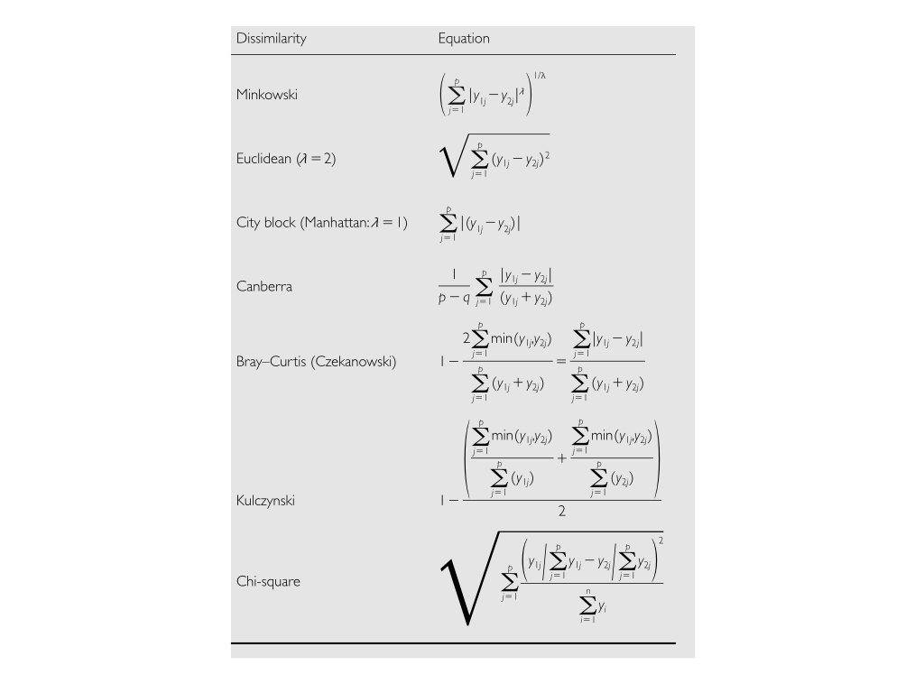

## Handling Missing Data in Multivariate Analysis

| Type | Description | Problem Severity |
| --- | --- | --- |
| **MCAR** | Missing Completely At Random | Least problematic |
| **MAR** | Missing At Random | Moderate concern |
| **MBC** | Missing But Correlated | Most problematic |

**Three Main Approaches**

1. **Deletion** — remove observations with missing values (simple but loses information)
2. **Imputation** — infer missing values (mean/median or multiple imputation)
3. **Maximum Likelihood / EM** — use all available data (most sophisticated)

# MANOVA — Multivariate Analysis of Variance

## Why Use MANOVA?

- When interested in the relationship of **two or more response variables** and one or more predictor variables
- Tests whether **group centroids** differ across multiple variables simultaneously
- More powerful than running separate univariate ANOVAs when response variables are correlated
- Equation
- LaTeX

$$H_0: \boldsymbol{\mu}_1 = \boldsymbol{\mu}_2 = \ldots = \boldsymbol{\mu}_k$$

```
H_0: \boldsymbol{\mu}_1 = \boldsymbol{\mu}_2 = \ldots = \boldsymbol{\mu}_k
```

## MANOVA Linear Model

Single Factor MANOVA uses a linear combination of p response variables:

- Equation
- Key Matrices

$$z_{ik} = c_1 y_{i1} + c_2 y_{i2} + c_3 y_{i3} + \ldots + c_p y_{ip}$$

- **H matrix**: Between-groups sums of squares and cross-products
- **E matrix**: Within-groups sums of squares and cross-products
- **T matrix**: Total sums of squares and cross-products
- The ratio H/E is decomposed into eigenvalues and eigenvectors

## MANOVA Test Statistics

| Statistic | Description | Use When |
| --- | --- | --- |
| **Wilk’s Lambda** | Most commonly used | General purpose |
| **Pillai’s Trace** | Most robust | Assumption violations |
| **Hotelling-Lawley** | Most powerful | Assumptions met |
| **Roy’s Largest Root** | Examines first eigenvalue | Few response variables |

## MANOVA in R

- Output
- Code

```
           Df Pillai approx F num Df den Df    Pr(>F)
Species     2 1.1919   53.466      8    290 < 2.2e-16 ***
Residuals 147
---
Signif. codes:  0 '***' 0.001 '**' 0.01 '*' 0.05 '.' 0.1 ' ' 1
```

```r
iris_manova <- manova(cbind(Sepal.Length, Sepal.Width,
                            Petal.Length, Petal.Width) ~ Species,
                      data = iris)

# Different test statistics
summary(iris_manova, test = "Pillai")
summary(iris_manova, test = "Wilks")
summary(iris_manova, test = "Hotelling-Lawley")

# Follow up with univariate ANOVAs
summary.aov(iris_manova)
```

## MANOVA Assumptions

1. **Multivariate Normality** — less critical for Pillai’s trace
2. **Homogeneity of Variance-Covariance** — test with Box’s M
3. **Independence** of observations
4. **No Multicollinearity** among response variables

**Outliers**

MANOVA is very sensitive to multivariate outliers. Use **Mahalanobis distance** to detect them.

## Detecting Multivariate Outliers

- Output
- Code

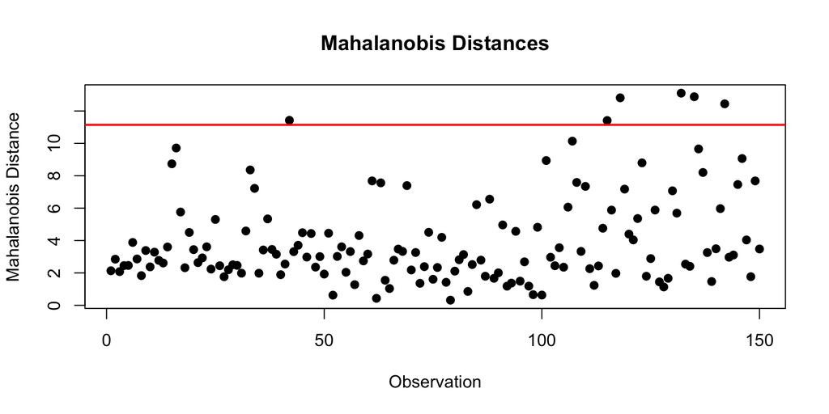

```r
iris_numeric <- iris[, 1:4]
center <- colMeans(iris_numeric)
cov_matrix <- cov(iris_numeric)
mahal_dist <- mahalanobis(iris_numeric, center, cov_matrix)

plot(mahal_dist, pch = 19, main = "Mahalanobis Distances",
     ylab = "Mahalanobis Distance", xlab = "Observation")
abline(h = qchisq(0.975, df = 4), col = "red", lwd = 2)
```

## MANOVA Follow-Up Workflow

After a significant MANOVA, determine **which variables** drive the group differences:

- Code
- Workflow Summary

```r
# Step 1: MANOVA
manova_result <- manova(cbind(Sepal.Length, Sepal.Width,
                               Petal.Length, Petal.Width) ~ Species,
                         data = iris)
summary(manova_result, test = "Pillai")

# Step 2: Univariate follow-up ANOVAs
summary.aov(manova_result)

# Step 3: Post-hoc pairwise comparisons for each response
library(emmeans)
for (var in c("Sepal.Length", "Sepal.Width",
              "Petal.Length", "Petal.Width")) {
  cat("\n---", var, "---\n")
  fit <- lm(as.formula(paste(var, "~ Species")), data = iris)
  em <- emmeans(fit, pairwise ~ Species, adjust = "bonferroni")
  print(em$contrasts)
}

# Step 4: Effect sizes (eta-squared for each variable)
library(car)
for (var in c("Sepal.Length", "Sepal.Width",
              "Petal.Length", "Petal.Width")) {
  fit <- lm(as.formula(paste(var, "~ Species")), data = iris)
  aov_table <- Anova(fit, type = "II")
  ss_group <- aov_table$`Sum Sq`[1]
  ss_total <- sum(aov_table$`Sum Sq`)
  cat(var, "eta² =", round(ss_group / ss_total, 3), "\n")
}
```

1. **MANOVA**: Test overall multivariate difference → significant?
2. **Univariate ANOVAs**: Which response variables differ?
3. **Post-hoc tests**: Which groups differ on each variable?
4. **Effect sizes**: How large are the differences?
5. **DFA/LDA**: Which combinations of variables best discriminate groups?

# Discriminant Function Analysis (DFA / LDA)

## MANOVA vs DFA

| Aspect | MANOVA | DFA |
| --- | --- | --- |
| **Purpose** | Hypothesis testing | Classification & prediction |
| **Question** | Do groups differ? | Which group does a new observation belong to? |
| **Output** | F-statistic, p-value | Discriminant functions, predictions |
| **Focus** | First discriminant function | All discriminant functions |

Both methods use the same underlying mathematics (eigendecomposition of H/E) but for different purposes.

## DFA Steps

1. **Run MANOVA** to test for group differences
   - If not significant, DFA won’t be useful
2. **Calculate Linear Discriminant Functions (LDF)**
   - Evaluate distributions of LDF scores
   - Do groups have separate distributions?
3. **Classify observations**
   - Generate conditional (posterior) probabilities
   - Determine percentage of correct assignments
   - Can train on one dataset and predict on new data

## Linear Discriminant Analysis in R

- Output
- Code

```
                    LD1         LD2
Sepal.Length  0.8293776 -0.02410215
Sepal.Width   1.5344731 -2.16452123
Petal.Length -2.2012117  0.93192121
Petal.Width  -2.8104603 -2.83918785
```

```r
library(MASS)

# Fit LDA model
iris_lda <- lda(Species ~ Sepal.Length + Sepal.Width +
                         Petal.Length + Petal.Width,
               data = iris)

# View discriminant function coefficients
iris_lda$scaling
```

## LDA Predictions and Classification

- Output
- Code

```
            Actual
Predicted    setosa versicolor virginica
  setosa         50          0         0
  versicolor      0         48         1
  virginica       0          2        49
```

```r
# Make predictions
iris_pred <- predict(iris_lda)

# Confusion matrix
table(Predicted = iris_pred$class, Actual = iris$Species)
```

## Visualizing Discriminant Functions

- Output
- Code

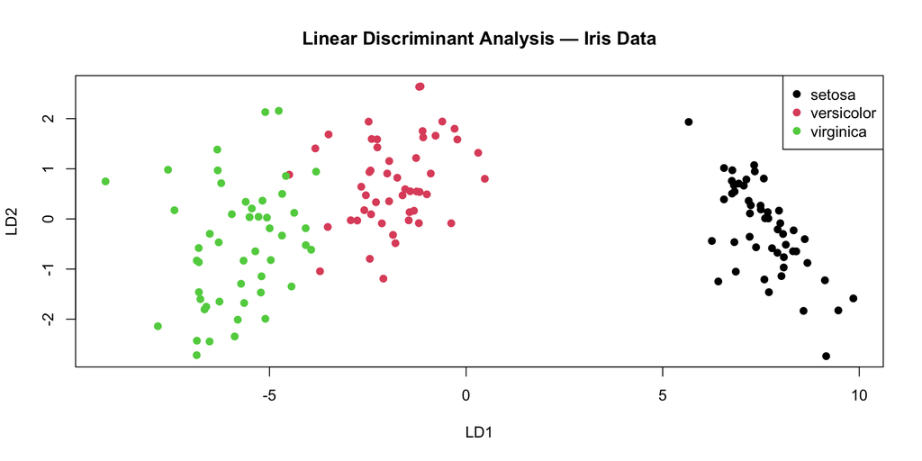

```r
lda_scores <- predict(iris_lda)$x
plot(lda_scores[, 1], lda_scores[, 2],
     col = as.numeric(iris$Species), pch = 19,
     xlab = "LD1", ylab = "LD2",
     main = "Linear Discriminant Analysis — Iris Data")
legend("topright", levels(iris$Species),
       col = 1:3, pch = 19)
```

## LDA for New Predictions

- Output
- Code

```
[1] setosa     versicolor virginica
Levels: setosa versicolor virginica
```

```
  setosa versicolor virginica
1      1      0.000     0.000
2      0      0.999     0.001
3      0      0.000     1.000
```

```r
# Create new observations
new_flowers <- data.frame(
  Sepal.Length = c(5.0, 6.5, 7.0),
  Sepal.Width  = c(3.5, 3.0, 3.2),
  Petal.Length  = c(1.4, 4.5, 6.0),
  Petal.Width   = c(0.2, 1.5, 2.0)
)

# Predict species
predict(iris_lda, new_flowers)$class

# Get posterior probabilities
round(predict(iris_lda, new_flowers)$posterior, 3)
```

## Logistic Regression as Classification

Recall from Week 8 that logistic regression can also be used for classification. The key differences from LDA:

| Aspect | LDA | Logistic Regression |
| --- | --- | --- |
| **Assumption** | Multivariate normal predictors | No distributional assumption |
| **Output** | Discriminant scores + classes | Log-odds + probabilities |
| **Best for** | Well-separated groups, normal data | Binary outcomes, mixed data types |
| **Multi-class** | Natural extension | Requires one-vs-rest |

**Tip**

Use LDA when you believe the predictors are approximately multivariate normal within each group. Use logistic regression when you have binary outcomes or non-normal predictors.

## LDA Cross-Validation for Honest Accuracy

Training and testing on the same data gives **overly optimistic** accuracy estimates. Use leave-one-out CV:

- Code
- Classifier Comparison

```r
library(MASS)

# LOOCV for LDA (built into MASS::lda!)
lda_cv <- lda(Species ~ ., data = iris, CV = TRUE)

# Honest classification accuracy
cv_accuracy <- mean(lda_cv$class == iris$Species)
cat("LDA LOOCV Accuracy:", round(cv_accuracy, 3))

# Confusion matrix from CV
table(Predicted = lda_cv$class, Actual = iris$Species)

# Compare with resubstitution (training accuracy — optimistic!)
lda_train <- lda(Species ~ ., data = iris)
train_pred <- predict(lda_train, iris)$class
train_accuracy <- mean(train_pred == iris$Species)
cat("\nTraining Accuracy:", round(train_accuracy, 3))
cat("\nCV Accuracy:     ", round(cv_accuracy, 3))
cat("\nDifference:      ", round(train_accuracy - cv_accuracy, 3))
```

```r
# Compare LDA vs. KNN vs. SVM via 10-fold CV
library(caret)
set.seed(42)
ctrl <- trainControl(method = "cv", number = 10)

# LDA
lda_cv_fit <- train(Species ~ ., data = iris, method = "lda",
                    trControl = ctrl)
# KNN
knn_cv_fit <- train(Species ~ ., data = iris, method = "knn",
                    trControl = ctrl, tuneGrid = data.frame(k = 1:15))
# SVM
svm_cv_fit <- train(Species ~ ., data = iris, method = "svmRadial",
                    trControl = ctrl)

# Compare results
results <- resamples(list(LDA = lda_cv_fit, KNN = knn_cv_fit, SVM = svm_cv_fit))
summary(results)
dotplot(results)
```

# BREAK

# Principal Component Analysis (PCA)

## What is PCA?

- **Dimensionality reduction** technique for continuous data
- Finds orthogonal directions (principal components) of **maximum variance**
- Transforms correlated variables into uncorrelated components
- First PC explains the most variance, second PC the next most, etc.

**Key Concepts**

- **Principal components**: new axes that maximize variance
- **Eigenvalues**: amount of variance explained by each PC
- **Loadings**: contribution of original variables to each PC
- **Scores**: coordinates of observations in PC space

## PCA in R

- Output
- Code

```
Importance of components:
                          PC1    PC2     PC3     PC4
Standard deviation     1.7084 0.9560 0.38309 0.14393
Proportion of Variance 0.7296 0.2285 0.03669 0.00518
Cumulative Proportion  0.7296 0.9581 0.99482 1.00000
```

```r
# PCA on iris data (excluding species)
pca_result <- prcomp(iris[, 1:4], scale. = TRUE)

# Variance explained
summary(pca_result)
```

## PCA Biplot

- Output
- Code

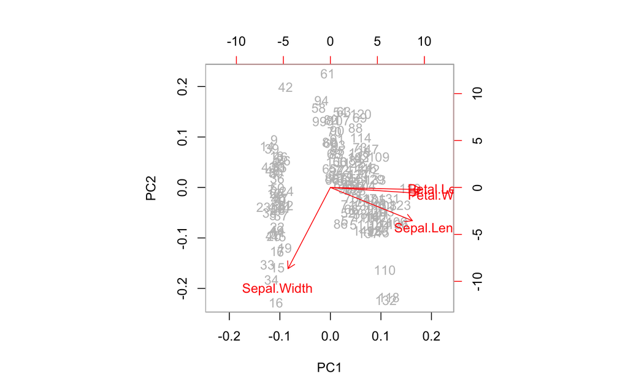

```r
biplot(pca_result, col = c("gray", "red"))
```

## Scree Plot

- Output
- Code

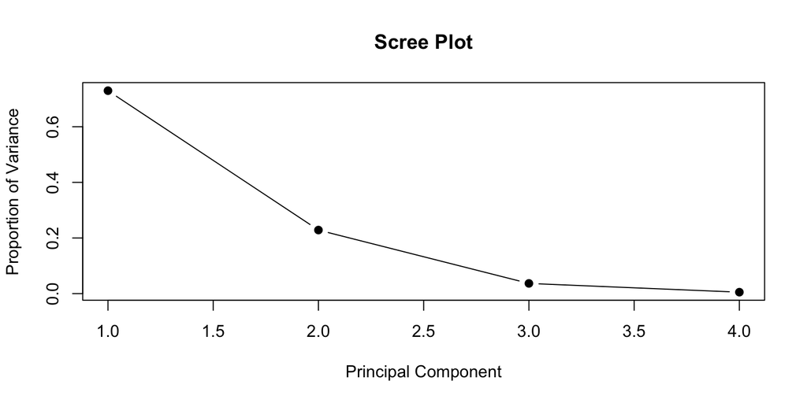

```r
var_explained <- pca_result$sdev^2 / sum(pca_result$sdev^2)

plot(var_explained, type = "b", pch = 19,
     xlab = "Principal Component", ylab = "Proportion of Variance",
     main = "Scree Plot")
```

## Interpreting PCA Loadings

The loadings (rotation matrix) tell you **which original variables contribute most** to each PC:

- Output
- Code
- Interpretation

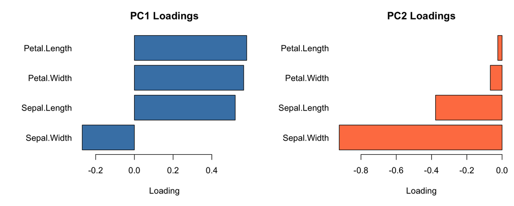

```r
# View the rotation (loadings) matrix
pca_result$rotation

# Loadings barplot
par(mfrow = c(1, 2), mar = c(5, 8, 3, 1))
barplot(sort(pca_result$rotation[, 1]), horiz = TRUE, las = 1,
        main = "PC1 Loadings", col = "steelblue")
barplot(sort(pca_result$rotation[, 2]), horiz = TRUE, las = 1,
        main = "PC2 Loadings", col = "coral")

# For many variables, use a heatmap of loadings
heatmap(pca_result$rotation, scale = "column",
        col = hcl.colors(50, "RdBu"),
        main = "PCA Loadings Heatmap")
```

- **Large positive loading**: variable increases along that PC direction
- **Large negative loading**: variable decreases
- **Near zero loading**: variable contributes little to that PC
- PC1 often represents overall size; PC2 often represents shape contrasts

## Publication-Quality PCA with ggplot2

- Output
- Code

[figure not shown]

```r
library(ggplot2)

# Extract scores and add grouping variable
pca_scores <- as.data.frame(pca_result$x)
pca_scores$Species <- iris$Species
var_exp <- round(100 * pca_result$sdev^2 / sum(pca_result$sdev^2), 1)

# ggplot PCA with 95% confidence ellipses
ggplot(pca_scores, aes(x = PC1, y = PC2, color = Species)) +
  geom_point(size = 2, alpha = 0.7) +
  stat_ellipse(level = 0.95, linewidth = 0.8) +
  labs(x = paste0("PC1 (", var_exp[1], "%)"),
       y = paste0("PC2 (", var_exp[2], "%)"),
       title = "PCA with 95% Confidence Ellipses") +
  scale_color_manual(values = c("steelblue", "coral", "forestgreen")) +
  theme_minimal(base_size = 14) +
  theme(legend.position = "bottom")
```

# PCoA and NMDS

## PCoA — Principal Coordinates Analysis

PCoA (also called classical multidimensional scaling) is similar to PCA but works on a **dissimilarity matrix** rather than raw data:

- Can use any distance metric (Bray-Curtis, Jaccard, UniFrac, etc.)
- Metric ordination: preserves actual distances
- Scores can be used in downstream linear models
- Code
- When to Use

```r
library(vegan)

# Calculate distance matrix
dist_matrix <- vegdist(my_data, method = "bray")

# Run PCoA
pcoa_result <- cmdscale(dist_matrix, k = 2, eig = TRUE)

# Plot
plot(pcoa_result$points, col = group_factor, pch = 19,
     xlab = "PCoA1", ylab = "PCoA2",
     main = "Principal Coordinates Analysis")
```

- When your dissimilarity metric matters (e.g., ecological data with Bray-Curtis)
- When you want metric ordination scores for downstream analysis
- When data are not suited for PCA (e.g., count data, presence/absence)

## PCoA: Community Data Example

- Output
- Code
- PERMANOVA Notes

[figure not shown]

```r
library(vegan)

# Calculate Bray-Curtis dissimilarity
dist_bc <- vegdist(community_data, method = "bray")

# Run PCoA
pcoa_res <- cmdscale(dist_bc, k = 2, eig = TRUE)

# Percent variance explained
var_exp <- round(100 * pcoa_res$eig[1:2] /
                 sum(pcoa_res$eig[pcoa_res$eig > 0]), 1)

# Plot with group labels
plot(pcoa_res$points, col = treatment, pch = 19,
     xlab = paste0("PCoA1 (", var_exp[1], "%)"),
     ylab = paste0("PCoA2 (", var_exp[2], "%)"),
     main = "PCoA (Bray-Curtis)")

# PERMANOVA: test if groups differ in multivariate space
adonis_result <- adonis2(dist_bc ~ treatment, permutations = 999)
print(adonis_result)

# Effect size: R² from PERMANOVA
cat("R² =", round(adonis_result$R2[1], 3))
```

- **PERMANOVA** (`adonis2()`) tests whether group centroids differ in multivariate space
- Works on any distance matrix (doesn’t require normality)
- R² gives the proportion of variation explained by the grouping
- Check **betadisper()** for homogeneity of dispersions (analogous to Levene’s test)

## NMDS — Non-metric Multidimensional Scaling

**NMDS** is a form of nonparametric ordination:

- Uses **rank-order** of dissimilarities rather than exact values
- Relaxes distributional assumptions
- Excellent for ecological, expression, and phenotypic data
- Works well when relationships are non-linear

## NMDS Algorithm

1. Calculate dissimilarity matrix between samples
2. Place points in reduced dimensional space (usually 2D)
3. Iteratively adjust positions to minimize **stress**
4. Stress measures how well ordination distances match dissimilarities

| Stress Value | Interpretation |
| --- | --- |
| < 0.05 | Excellent |
| 0.05–0.10 | Good |
| 0.10–0.20 | Acceptable |
| > 0.20 | Poor fit |

## NMDS in R with vegan

- Code
- Visualization

```r
library(vegan)

# Run NMDS
nmds_result <- metaMDS(my_data, distance = "bray", k = 2, trace = FALSE)

# Check stress value
print(nmds_result$stress)

# Stress plot: visualize fit between ordination and original distances
stressplot(nmds_result)
```

```r
# Color by grouping variable
plot(nmds_result$points, col = group_factor, pch = 19,
     xlab = "NMDS1", ylab = "NMDS2",
     main = "NMDS Ordination")
legend("topright", levels(group_factor),
       col = 1:nlevels(group_factor), pch = 19)
```

## PCA vs PCoA vs NMDS

| Aspect | PCA | PCoA | NMDS |
| --- | --- | --- | --- |
| **Input** | Covariance/Correlation | Dissimilarity matrix | Dissimilarity matrix |
| **Scaling** | Metric | Metric | Non-metric (ordinal) |
| **Assumptions** | Linear relationships | Any distance metric | Rank-order preservation |
| **Downstream** | Scores usable in linear models | Scores usable in linear models | **Cannot use in linear models** |

**Warning**

NMDS scores preserve only rank-order relationships, so they should **not** be used directly in regression or ANOVA!

## NMDS: Hypothesis Testing with PERMANOVA

- Code
- Interpretation

```r
library(vegan)

# Fit NMDS
nmds <- metaMDS(community_data, distance = "bray", k = 2, trymax = 100)

# PERMANOVA — test group differences on the distance matrix
dist_bc <- vegdist(community_data, method = "bray")
perm_result <- adonis2(dist_bc ~ treatment, permutations = 999)
print(perm_result)

# Check dispersion homogeneity (assumption of PERMANOVA)
disp <- betadisper(dist_bc, treatment)
permutest(disp, permutations = 999)

# envfit — fit environmental variables onto ordination
env_data <- data.frame(pH = rnorm(nrow(community_data), 7, 0.5),
                       temperature = rnorm(nrow(community_data), 37, 2))
ef <- envfit(nmds, env_data, permutations = 999)
print(ef)

# Plot NMDS with envfit vectors
plot(nmds, type = "n", main = "NMDS with Environmental Vectors")
points(nmds, col = treatment, pch = 19)
plot(ef, p.max = 0.05, col = "red", lwd = 2)
```

- **PERMANOVA** (adonis2): Tests whether group centroids differ; report R² and p-value
- **betadisper**: Checks if groups have similar spread (a PERMANOVA assumption)
- **envfit**: Fits continuous environmental variables as vectors onto the ordination; arrow direction and length show correlation strength
- Only plot envfit vectors that are significant (p < 0.05)

# t-SNE and UMAP

## What is t-SNE?

**t-Distributed Stochastic Neighbor Embedding** — a non-linear dimensionality reduction method:

- Preserves **local structure** (nearby points stay nearby)
- Excellent for visualization of high-dimensional clusters
- Not for inference or preserving global structure

| Parameter | Description | Typical Values |
| --- | --- | --- |
| perplexity | Balance between local/global structure | 5–50 |
| iterations | Number of optimization steps | 1000+ |
| learning_rate | Step size for optimization | 100–1000 |

## t-SNE in R

- Code
- Important Notes

```r
library(Rtsne)

# Run t-SNE
tsne_result <- Rtsne(iris[, 1:4],
                     perplexity = 30,
                     dims = 2,
                     verbose = TRUE)

# Plot
plot(tsne_result$Y, col = iris$Species, pch = 19,
     xlab = "t-SNE 1", ylab = "t-SNE 2",
     main = "t-SNE of Iris Data")
legend("topright", levels(iris$Species), col = 1:3, pch = 19)
```

- Results depend on random initialization — set a seed!
- Perplexity affects results significantly
- **Don’t interpret distances between clusters** — only within-cluster structure is meaningful
- Not deterministic — run multiple times and compare

## What is UMAP?

**Uniform Manifold Approximation and Projection** — similar goals to t-SNE but with key advantages:

- Faster computation (scales better to large datasets)
- Better preserves **global structure** (relative cluster positions are meaningful)
- More reproducible
- Can project new data onto an existing embedding

| Parameter | Description | Typical Values |
| --- | --- | --- |
| n_neighbors | Size of local neighborhood | 5–50 |
| min_dist | Minimum distance between points | 0.001–0.5 |
| n_components | Number of output dimensions | 2–3 |

## UMAP in R

- Code
- Comparing Methods

```r
library(umap)

# Run UMAP
umap_result <- umap(iris[, 1:4])

# Plot
plot(umap_result$layout, col = iris$Species, pch = 19,
     xlab = "UMAP 1", ylab = "UMAP 2",
     main = "UMAP of Iris Data")
legend("topright", levels(iris$Species), col = 1:3, pch = 19)
```

| Method | Speed | Global Structure | Local Structure | Reproducible |
| --- | --- | --- | --- | --- |
| PCA | Fast | Preserved | Less accurate | Yes |
| t-SNE | Slow | Lost | Excellent | No |
| UMAP | Medium | Good | Excellent | Mostly |

## When to Use Each Dimensionality Reduction Method

**Recommendations**

- **PCA**: Initial exploration, feature extraction, preprocessing, when you need interpretable axes
- **PCoA**: When your distance metric matters (ecology, microbiome data)
- **NMDS**: When rank-order relationships are more meaningful than exact distances
- **t-SNE**: Publication-quality visualization of clusters in high-dimensional data
- **UMAP**: Large datasets, when you need both global and local structure preserved